# Examen Modulo 5

Lucia Pena Pais

15/6/2021

## Preprocesado

### 1. Análisis descriptivo de las variables.

```r
suppressPackageStartupMessages(library(readr))
setwd("C:/Users/Usuario/Documents/Master BI/M5 - Minería de Datos I/Evaluación M5")
train <- read_csv("train.csv")
test <- read_csv("test.csv")
train <- as.data.frame(train)
test <- as.data.frame(test)
str(train)
```

```
## 'data.frame':    76480 obs. of  14 variables:
##  $ price        : num  1750000 8498000 5100000 9151965 1669676 ...
##  $ date         : Date, format: "2019-11-13" "2020-02-10" ...
##  $ time         : 'hms' num  13:01:13 12:47:05 08:24:07 12:52:30 ...
##   ..- attr(*, "units")= chr "secs"
##  $ geo_lat      : num  46.7 55.6 56.7 55.9 55 ...
##  $ geo_lon      : num  38.3 37.6 37.2 37.4 83 ...
##  $ region       : num  2843 3 81 81 9654 ...
##  $ building_type: num  3 1 3 2 1 2 0 0 3 1 ...
##  $ level        : num  3 2 1 4 2 11 13 3 6 2 ...
##  $ levels       : num  5 9 9 10 10 17 14 7 12 10 ...
##  $ rooms        : num  1 3 2 2 3 3 1 2 3 1 ...
##  $ area         : num  33 50 57 57 59 ...
##  $ kitchen_area : num  10 9 11 10.2 8.51 ...
##  $ object_type  : num  1 1 1 11 11 1 1 1 1 11 ...
##  $ id           : num  212238 193894 106354 48461 228556 ...
##  - attr(*, "spec")=
##   .. cols(
##   ..   price = col_double(),
##   ..   date = col_date(format = ""),
##   ..   time = col_time(format = ""),
##   ..   geo_lat = col_double(),
##   ..   geo_lon = col_double(),
##   ..   region = col_double(),
##   ..   building_type = col_double(),
##   ..   level = col_double(),
##   ..   levels = col_double(),
##   ..   rooms = col_double(),
##   ..   area = col_double(),
##   ..   kitchen_area = col_double(),
##   ..   object_type = col_double(),
##   ..   id = col_double()
##   .. )
```

```r
str(test)
```

```
## 'data.frame':    5873 obs. of  14 variables:
##  $ price        : num  2700000 1850000 1250000 2000000 1150000 ...
##  $ date         : Date, format: "2020-04-17" "2019-04-29" ...
##  $ time         : 'hms' num  05:28:18 10:52:39 11:53:57 20:03:57 ...
##   ..- attr(*, "units")= chr "secs"
##  $ geo_lat      : num  55 53.3 56.4 60 45.4 ...
##  $ geo_lon      : num  83 83.6 58.5 30.4 40.5 ...
##  $ region       : num  9654 6817 6171 2661 2843 ...
##  $ building_type: num  1 1 5 3 3 3 3 2 3 3 ...
##  $ level        : num  1 3 2 8 1 3 10 10 6 5 ...
##  $ levels       : num  5 9 2 18 5 5 10 24 16 9 ...
##  $ rooms        : num  3 3 2 -1 1 3 1 1 1 2 ...
##  $ area         : num  58 67 41.2 21 35.4 73.9 44.6 40 36 51.7 ...
##  $ kitchen_area : num  7 8 7.2 5 8.1 8.7 10.9 12.6 9 9 ...
##  $ object_type  : num  1 1 1 11 1 1 1 1 1 11 ...
##  $ id           : num  79257 245926 105470 49975 94136 ...
##  - attr(*, "spec")=
##   .. cols(
##   ..   price = col_double(),
##   ..   date = col_date(format = ""),
##   ..   time = col_time(format = ""),
##   ..   geo_lat = col_double(),
##   ..   geo_lon = col_double(),
##   ..   region = col_double(),
##   ..   building_type = col_double(),
##   ..   level = col_double(),
##   ..   levels = col_double(),
##   ..   rooms = col_double(),
##   ..   area = col_double(),
##   ..   kitchen_area = col_double(),
##   ..   object_type = col_double(),
##   ..   id = col_double()
##   .. )
```

Vamos a unir los dos datasets para realizar el preprocesado. Añadiremos una columna indicando a que dataset pertenece para después separarlos de nuevo en la modelización.

```r
train$dataset <- "train"
test$dataset <- "test"

suppressPackageStartupMessages(library(dplyr))

datos <- bind_rows(train,test)
str(datos)
```

```
## 'data.frame':    82353 obs. of  15 variables:
##  $ price        : num  1750000 8498000 5100000 9151965 1669676 ...
##  $ date         : Date, format: "2019-11-13" "2020-02-10" ...
##  $ time         : 'hms' num  13:01:13 12:47:05 08:24:07 12:52:30 ...
##   ..- attr(*, "units")= chr "secs"
##  $ geo_lat      : num  46.7 55.6 56.7 55.9 55 ...
##  $ geo_lon      : num  38.3 37.6 37.2 37.4 83 ...
##  $ region       : num  2843 3 81 81 9654 ...
##  $ building_type: num  3 1 3 2 1 2 0 0 3 1 ...
##  $ level        : num  3 2 1 4 2 11 13 3 6 2 ...
##  $ levels       : num  5 9 9 10 10 17 14 7 12 10 ...
##  $ rooms        : num  1 3 2 2 3 3 1 2 3 1 ...
##  $ area         : num  33 50 57 57 59 ...
##  $ kitchen_area : num  10 9 11 10.2 8.51 ...
##  $ object_type  : num  1 1 1 11 11 1 1 1 1 11 ...
##  $ id           : num  212238 193894 106354 48461 228556 ...
##  $ dataset      : chr  "train" "train" "train" "train" ...
##  - attr(*, "spec")=
##   .. cols(
##   ..   price = col_double(),
##   ..   date = col_date(format = ""),
##   ..   time = col_time(format = ""),
##   ..   geo_lat = col_double(),
##   ..   geo_lon = col_double(),
##   ..   region = col_double(),
##   ..   building_type = col_double(),
##   ..   level = col_double(),
##   ..   levels = col_double(),
##   ..   rooms = col_double(),
##   ..   area = col_double(),
##   ..   kitchen_area = col_double(),
##   ..   object_type = col_double(),
##   ..   id = col_double()
##   .. )
```

Transformamos en factores las variables necesarias

```r
datos$region <- as.factor(datos$region)

datos$building_type <- factor(datos$building_type, labels = c("Otro", "Panel", "Monolítico", "Ladrillo", "Blocky", "Madera"))

datos$object_type <- factor(datos$object_type,labels = c("Mercado secundario", "Edificio nuevo"))

datos$level <- as.factor(datos$level)
datos$levels <- as.factor(datos$levels)
datos$rooms <- as.factor(datos$rooms)
datos$dataset <- as.factor(datos$dataset)

str(datos)
```

```
## 'data.frame':    82353 obs. of  15 variables:
##  $ price        : num  1750000 8498000 5100000 9151965 1669676 ...
##  $ date         : Date, format: "2019-11-13" "2020-02-10" ...
##  $ time         : 'hms' num  13:01:13 12:47:05 08:24:07 12:52:30 ...
##   ..- attr(*, "units")= chr "secs"
##  $ geo_lat      : num  46.7 55.6 56.7 55.9 55 ...
##  $ geo_lon      : num  38.3 37.6 37.2 37.4 83 ...
##  $ region       : Factor w/ 82 levels "3","69","81",..: 18 1 3 3 70 18 3 54 70 70 ...
##  $ building_type: Factor w/ 6 levels "Otro","Panel",..: 4 2 4 3 2 3 1 1 4 2 ...
##  $ level        : Factor w/ 36 levels "1","2","3","4",..: 3 2 1 4 2 11 13 3 6 2 ...
##  $ levels       : Factor w/ 39 levels "1","2","3","4",..: 5 9 9 10 10 17 14 7 12 10 ...
##  $ rooms        : Factor w/ 11 levels "-2","-1","1",..: 3 5 4 4 5 5 3 4 5 3 ...
##  $ area         : num  33 50 57 57 59 ...
##  $ kitchen_area : num  10 9 11 10.2 8.51 ...
##  $ object_type  : Factor w/ 2 levels "Mercado secundario",..: 1 1 1 2 2 1 1 1 1 2 ...
##  $ id           : num  212238 193894 106354 48461 228556 ...
##  $ dataset      : Factor w/ 2 levels "test","train": 2 2 2 2 2 2 2 2 2 2 ...
##  - attr(*, "spec")=
##   .. cols(
##   ..   price = col_double(),
##   ..   date = col_date(format = ""),
##   ..   time = col_time(format = ""),
##   ..   geo_lat = col_double(),
##   ..   geo_lon = col_double(),
##   ..   region = col_double(),
##   ..   building_type = col_double(),
##   ..   level = col_double(),
##   ..   levels = col_double(),
##   ..   rooms = col_double(),
##   ..   area = col_double(),
##   ..   kitchen_area = col_double(),
##   ..   object_type = col_double(),
##   ..   id = col_double()
##   .. )
```

Tenemos 15 variables, 7 de tipo factor, 5 numéricas, 2 en formato fecha y hora, y la variable id.

```r
summary(datos)
```

```
##      price                 date                time             geo_lat
##  Min.   :-2.114e+09   Min.   :2018-09-08   Length:82353      Min.   :41.46
##  1st Qu.: 1.950e+06   1st Qu.:2019-03-14   Class1:hms        1st Qu.:53.37
##  Median : 2.990e+06   Median :2019-10-14   Class2:difftime   Median :55.17
##  Mean   : 4.312e+06   Mean   :2019-11-20   Mode  :numeric    Mean   :54.04
##  3rd Qu.: 4.800e+06   3rd Qu.:2020-07-19                     3rd Qu.:56.22
##  Max.   : 1.144e+09   Max.   :2021-05-01                     Max.   :69.50
##
##     geo_lon           region         building_type       level
##  Min.   : 19.95   9654   :15799   Otro      : 4527   2      :10584
##  1st Qu.: 37.78   2843   : 9592   Panel     :29411   1      :10205
##  Median : 43.07   81     : 7584   Monolítico:17038   3      : 9038
##  Mean   : 53.23   2661   : 6883   Ladrillo  :28453   5      : 8853
##  3rd Qu.: 65.63   3      : 6555   Blocky    : 2694   4      : 8480
##  Max.   :158.70   6171   : 3544   Madera    :  230   6      : 4932
##                   (Other):32396                      (Other):30261
##      levels          rooms            area          kitchen_area
##  5      :15263   1      :31155   Min.   :   1.00   Min.   :  0.05
##  10     :14255   2      :27291   1st Qu.:  38.10   1st Qu.:  7.00
##  9      :11002   3      :16613   Median :  48.10   Median :  9.70
##  17     : 5175   -1     : 4596   Mean   :  53.98   Mean   : 10.63
##  16     : 4604   4      : 2275   3rd Qu.:  63.10   3rd Qu.: 12.70
##  25     : 3187   5      :  359   Max.   :4701.00   Max.   :444.00
##  (Other):28867   (Other):   64
##              object_type          id          dataset
##  Mercado secundario:58047   Min.   :     6   test : 5873
##  Edificio nuevo    :24306   1st Qu.: 68552   train:76480
##                             Median :136662
##                             Mean   :137030
##                             3rd Qu.:205750
##                             Max.   :273850
##
```

Podemos ver las frecuencias en las variables categóricas, por ejemplo, vemos que hay más inmuebles con fachadas de tipo Panel y Ladrillo, y muchas menos de tipo Madera.

También podemos ver algunos datos estadísticos en las variables cuantitativas, como que la media del area de los inmuebles es de 53.98 y el de las cocinas de 10.63.

En la variable precio vemos que el mínimo es negativo, lo cual hace sospechar de valores outliers erróneos.

```r
suppressPackageStartupMessages(library(skimr))
skim(datos)
```

Data summary

| Name | datos |
| --- | --- |
| Number of rows | 82353 |
| Number of columns | 15 |
| _______________________ |  |
| Column type frequency: |  |
| Date | 1 |
| difftime | 1 |
| factor | 7 |
| numeric | 6 |
| ________________________ |  |
| Group variables | None |

**Variable type: Date**

| skim_variable | n_missing | complete_rate | min | max | median | n_unique |
| --- | --- | --- | --- | --- | --- | --- |
| date | 0 | 1 | 2018-09-08 | 2021-05-01 | 2019-10-14 | 966 |

**Variable type: difftime**

| skim_variable | n_missing | complete_rate | min | max | median | n_unique |
| --- | --- | --- | --- | --- | --- | --- |
| time | 0 | 1 | 4 secs | 86396 secs | 12:21:27 | 49830 |

**Variable type: factor**

| skim_variable | n_missing | complete_rate | ordered | n_unique | top_counts |
| --- | --- | --- | --- | --- | --- |
| region | 0 | 1 | FALSE | 82 | 965: 15799, 284: 9592, 81: 7584, 266: 6883 |
| building_type | 0 | 1 | FALSE | 6 | Pan: 29411, Lad: 28453, Mon: 17038, Otr: 4527 |
| level | 0 | 1 | FALSE | 36 | 2: 10584, 1: 10205, 3: 9038, 5: 8853 |
| levels | 0 | 1 | FALSE | 39 | 5: 15263, 10: 14255, 9: 11002, 17: 5175 |
| rooms | 0 | 1 | FALSE | 11 | 1: 31155, 2: 27291, 3: 16613, -1: 4596 |
| object_type | 0 | 1 | FALSE | 2 | Mer: 58047, Edi: 24306 |
| dataset | 0 | 1 | FALSE | 2 | tra: 76480, tes: 5873 |

**Variable type: numeric**

| skim_variable | n_missing | complete_rate | mean | sd | p0 | p25 | p50 | p75 | p100 | hist |
| --- | --- | --- | --- | --- | --- | --- | --- | --- | --- | --- |
| price | 0 | 1 | 4312181.31 | 17593915.94 | -2.11415e+09 | 1950000.00 | 2990000.00 | 4800000.00 | 1144262000.0 | ▁▁▁▇▁ |
| geo_lat | 0 | 1 | 54.04 | 4.62 | 4.14600e+01 | 53.37 | 55.17 | 56.22 | 69.5 | ▂▁▇▁▁ |
| geo_lon | 0 | 1 | 53.23 | 20.71 | 1.99500e+01 | 37.78 | 43.07 | 65.63 | 158.7 | ▇▃▃▁▁ |
| area | 0 | 1 | 53.98 | 34.91 | 1.00000e+00 | 38.10 | 48.10 | 63.10 | 4701.0 | ▇▁▁▁▁ |
| kitchen_area | 0 | 1 | 10.63 | 6.10 | 5.00000e-02 | 7.00 | 9.70 | 12.70 | 444.0 | ▇▁▁▁▁ |
| id | 0 | 1 | 137029.61 | 79046.53 | 6.00000e+00 | 68552.00 | 136662.00 | 205750.00 | 273850.0 | ▇▇▇▇▇ |

Vemos que no hay valores ausentes en ninguna de las variables.

Para la variable fecha, vemos que el primer anuncio publicado fue 08/09/2018 y el último el 01/05/2021.

La variable precio y también la latitud, parecen seguir una distribución Normal. En cambio longitud, area y kitchen_area parecen tener una distribución Poisson o Gamma con cola a la derecha.

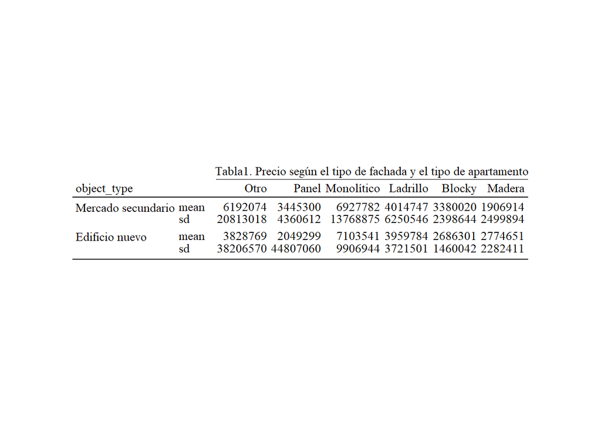

```r
suppressPackageStartupMessages(library(tables))
suppressPackageStartupMessages(library(tablesgg))
tabla1 <- tabular(object_type*Heading()*price*(mean+sd)~
                    Heading("Tabla1. Precio según el tipo de fachada y el tipo de apartamento")*building_type*Heading(), data = datos)
plot(textTable(tabla1))
```

En los inmuebles de segunda mano, vemos que la media de precios es más alta para los de fachada de tipo Monolítica u Otra (76.924,07 y 68.754,98 euros$^1$). Mientras que es mucho más baja para los de fachada de Madera (21.173,81 euros). También es cierto que la desviación de precios es mayor para los primeros.

Entre los apartamentos nuevos, el precio medio más alto sigue siendo el de los de tipo Monolítico (78.875,64 euros), mientras que el más bajo pasa ser el de los de tipo Panel (22754.81 euros).

Llama la atención que el precio medio, excepto para los Monolíticos y de Madera, es más bajo entre los edificios nuevos que en los de segunda mano.

$^1$*Nota: El precio está en rublos (1 euro equivale a 90,06 rublo ruso)*

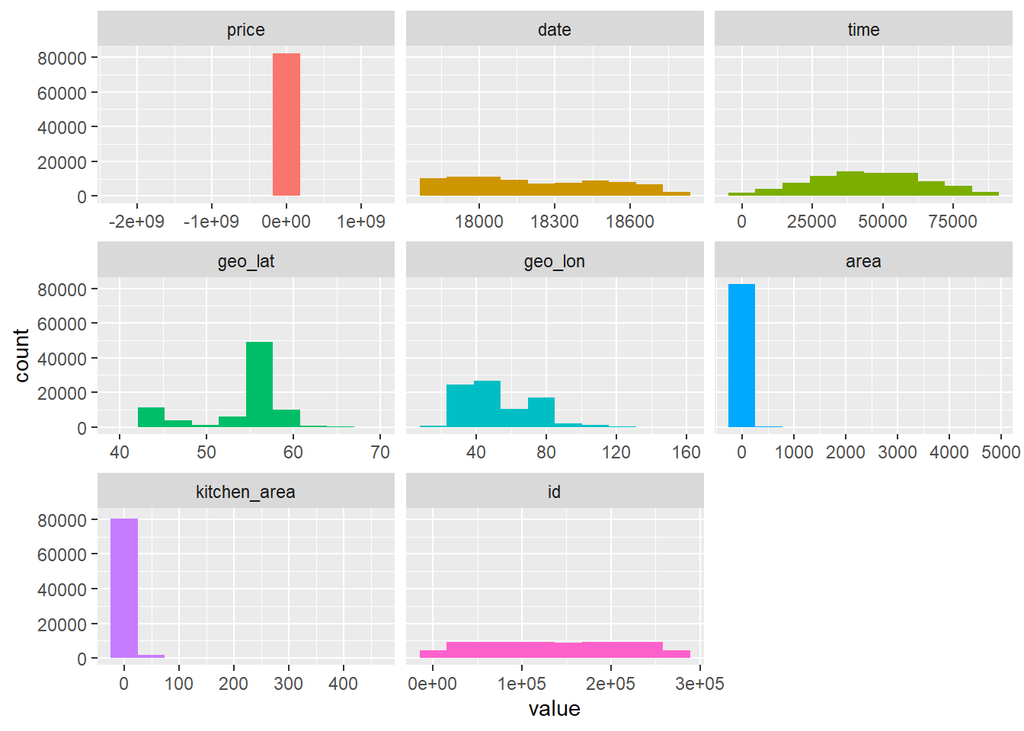

```r
suppressPackageStartupMessages(library(funModeling))
plot_num(datos)
```

Como comentábamos, las variables precio y latitud parecen tener una distribución Normal, mientras que el resto de variables númericas parecen tener una distribución Gamma o Poisson.

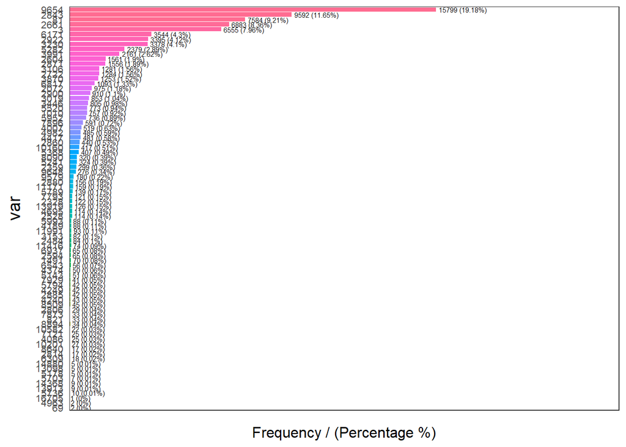

```
##      var frequency percentage cumulative_perc
## 1   9654     15799      19.18           19.18
## 2   2843      9592      11.65           30.83
## 3     81      7584       9.21           40.04
## 4   2661      6883       8.36           48.40
## 5      3      6555       7.96           56.36
## 6   6171      3544       4.30           60.66
## 7   2922      3395       4.12           64.78
## 8   3230      3378       4.10           68.88
## 9   5282      2379       2.89           71.77
## 10  3991      2161       2.62           74.39
## 11  2604      1561       1.90           76.29
## 12  2871      1556       1.89           78.18
## 13  2722      1284       1.56           79.74
## 14  3106      1281       1.56           81.30
```

[output cut: 68 more lines]

```r
freq(datos$region)
```

En este gráfico de frecuencias podemos ver que las regiones con mayor número de inmuebles a la venta son la 9654, la 2843 y la 81. Y las que menos son la 16705, 4963 y 69.

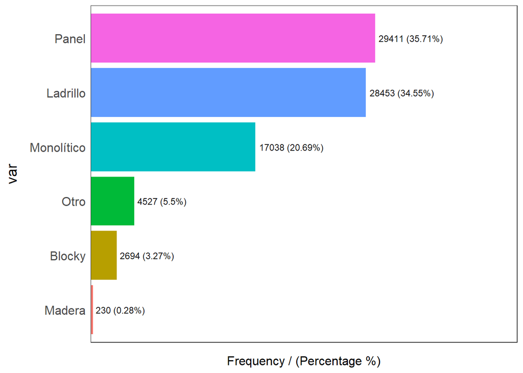

```
##          var frequency percentage cumulative_perc
## 1      Panel     29411      35.71           35.71
## 2   Ladrillo     28453      34.55           70.26
## 3 Monolítico     17038      20.69           90.95
## 4       Otro      4527       5.50           96.45
## 5     Blocky      2694       3.27           99.72
## 6     Madera       230       0.28          100.00
```

```r
freq(datos$building_type)
```

La mayor parte de los inmuebles tienen una fachada de tipo Panel o Ladrillo, mientras que solo 230 tienen fachada de Madera.

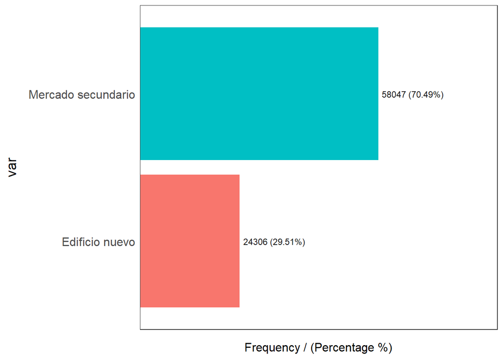

```
##                  var frequency percentage cumulative_perc
## 1 Mercado secundario     58047      70.49           70.49
## 2     Edificio nuevo     24306      29.51          100.00
```

```r
freq(datos$object_type)
```

Observamos que un 70% de los inmuebles en venta son de segunda mano.

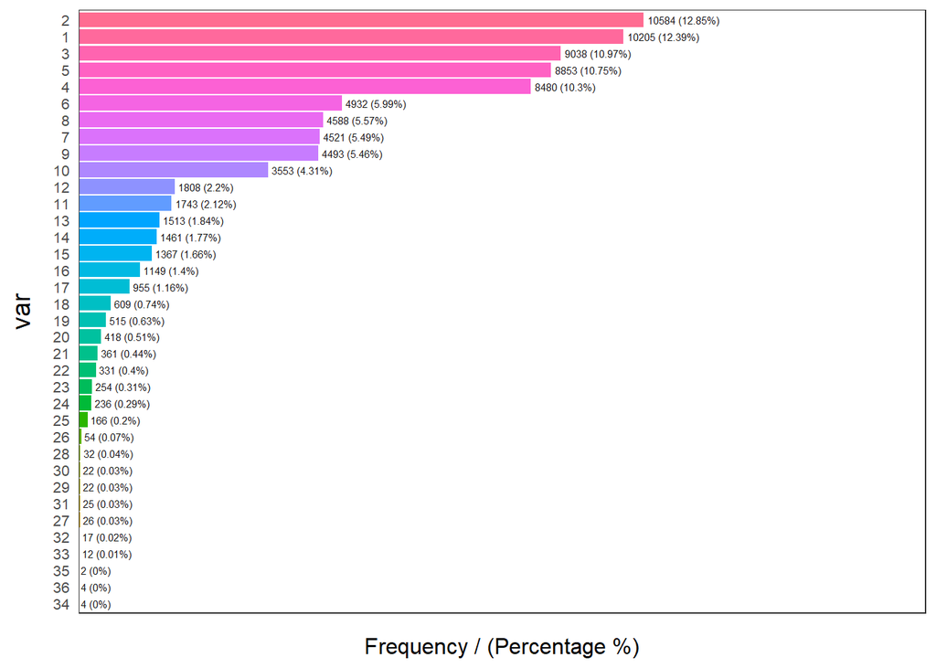

```
##    var frequency percentage cumulative_perc
## 1    2     10584      12.85           12.85
## 2    1     10205      12.39           25.24
## 3    3      9038      10.97           36.21
## 4    5      8853      10.75           46.96
## 5    4      8480      10.30           57.26
## 6    6      4932       5.99           63.25
## 7    8      4588       5.57           68.82
## 8    7      4521       5.49           74.31
## 9    9      4493       5.46           79.77
## 10  10      3553       4.31           84.08
## 11  12      1808       2.20           86.28
## 12  11      1743       2.12           88.40
## 13  13      1513       1.84           90.24
## 14  14      1461       1.77           92.01
```

[output cut: 22 more lines]

```r
freq(datos$level)
```

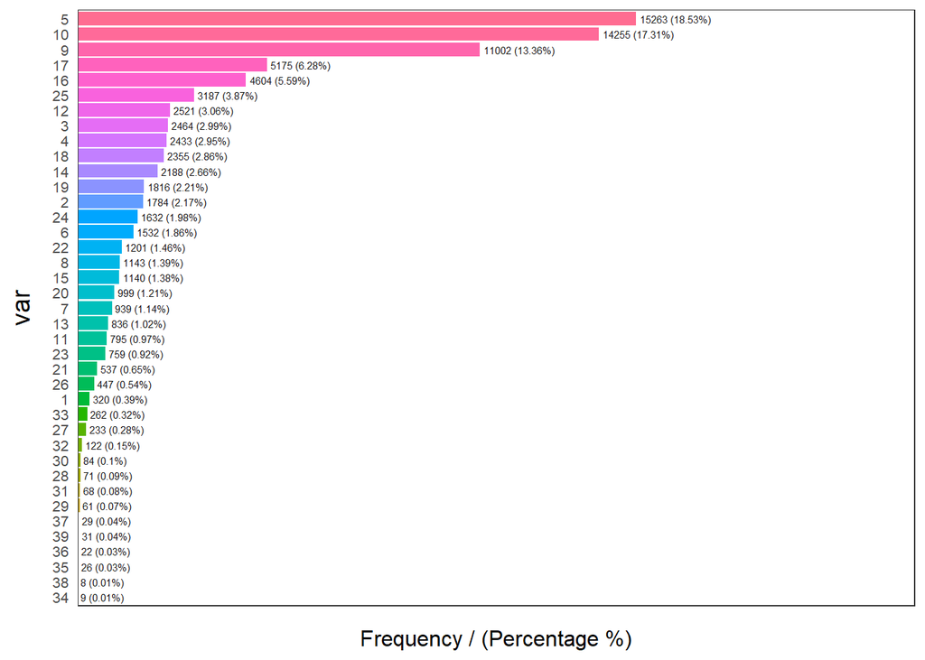

```
##    var frequency percentage cumulative_perc
## 1    5     15263      18.53           18.53
## 2   10     14255      17.31           35.84
## 3    9     11002      13.36           49.20
## 4   17      5175       6.28           55.48
## 5   16      4604       5.59           61.07
## 6   25      3187       3.87           64.94
## 7   12      2521       3.06           68.00
## 8    3      2464       2.99           70.99
## 9    4      2433       2.95           73.94
## 10  18      2355       2.86           76.80
## 11  14      2188       2.66           79.46
## 12  19      1816       2.21           81.67
## 13   2      1784       2.17           83.84
## 14  24      1632       1.98           85.82
```

[output cut: 25 more lines]

```r
freq(datos$levels)
```

A pesar de que los inmuebles en venta corresponden a apartamentos en plantas por debajo de la 5ª, casi el 50% son inmuebles con 5, 10 y 9 pisos. Esto nos da a entender que gran parte de los inmuebles corresponden a edificios y no a viviendas unifamiliares.

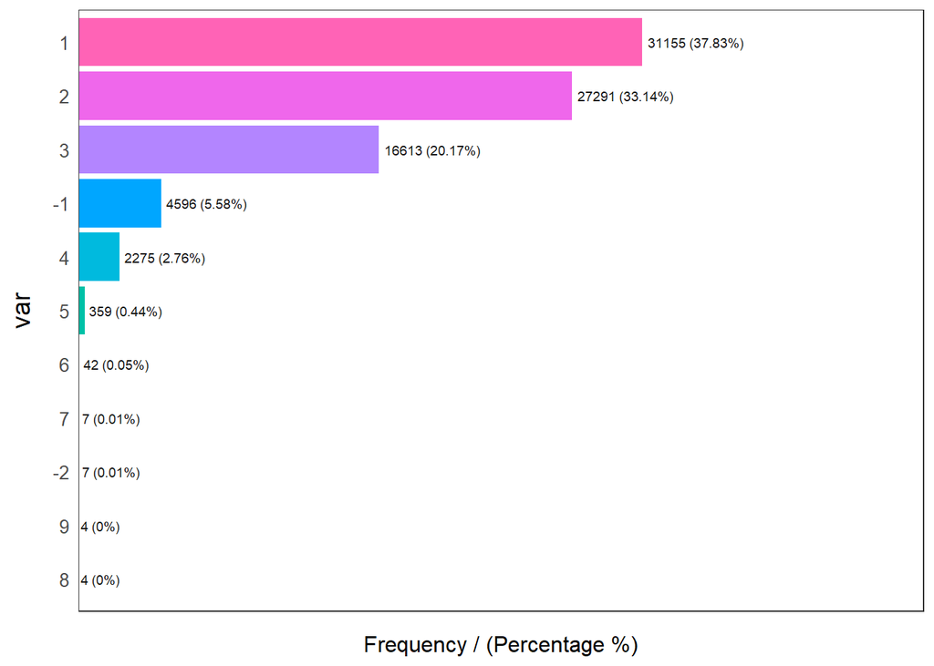

```
##    var frequency percentage cumulative_perc
## 1    1     31155      37.83           37.83
## 2    2     27291      33.14           70.97
## 3    3     16613      20.17           91.14
## 4   -1      4596       5.58           96.72
## 5    4      2275       2.76           99.48
## 6    5       359       0.44           99.92
## 7    6        42       0.05           99.97
## 8   -2         7       0.01           99.98
## 9    7         7       0.01           99.99
## 10   8         4       0.00           99.99
## 11   9         4       0.00          100.00
```

```r
freq(datos$rooms)
```

La mayor parte de los inmuebles tienen 1, 2 y 3 habitaciones, mientras que un 5% son apartamentos de tipo estudio (-1). Observamos que 7 inmuebles tienen -2 habitaciones, que entendemos se debe a un error en la recopilación de los datos, ya que no podría haber inmuebles con menos habitaciones que un estudio.

```r
#Creamos una función para realizar los gráficos de precio
suppressPackageStartupMessages(library(ggplot2))

grafico <- function(var, ylim){
  columna<-as.symbol(var)

 grafico1 <- ggplot(datos, aes(x=factor(!!columna), y = price)) +
  geom_boxplot(aes(fill = !!columna)) +
  coord_cartesian(ylim = c(0,ylim)) +
  ylab("Precio") +
  theme(axis.text.x = element_text(angle = 90)) +
  ggtitle(paste0("Precio según ", var)) +
  theme(legend.position = "none")

 grafico1
}
```

Indicamos el límite de la coordenada *y* como variable de la función, ya que para visualizar correctamente todos los gráficos necesitamos modificarlo.

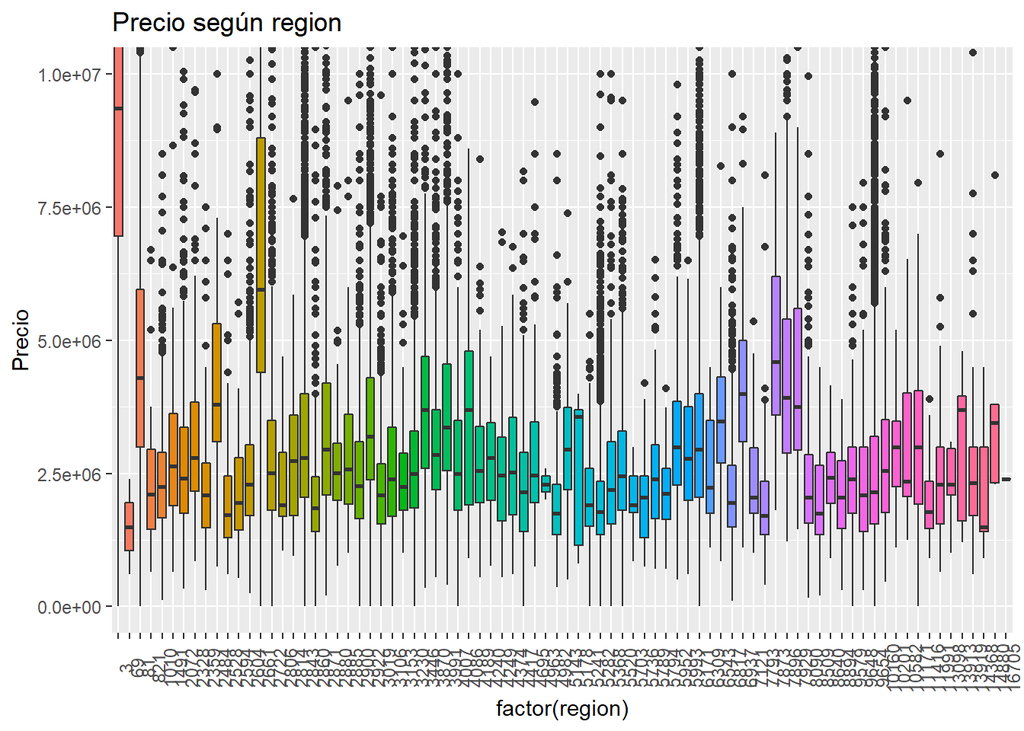

```r
grafico("region", 10000000)
```

Observamos que las regiones con mayores precios son la 3 y la 2661. Para el resto, las medias de precio son similares, teniendo en cuenta que el precio está en rublos rusos.

Las regiones con menores precios medios son la 69 y la 14368. También se puede ver la gran cantidad de valores outliers de la variable precio.

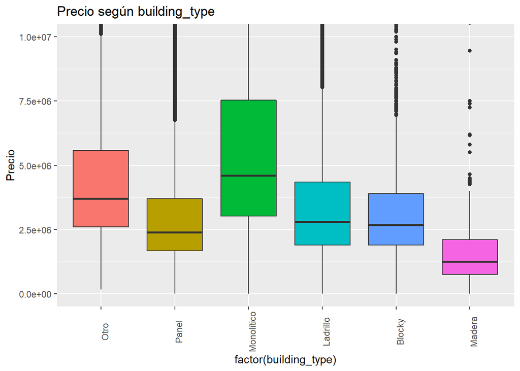

```r
grafico("building_type", 10000000)
```

Tal y como veíamos en la tabla anterior, los edificios de tipo Monolítico y Otro son los de mayor precio, mientras que los de Madera tienen los precios más bajos.

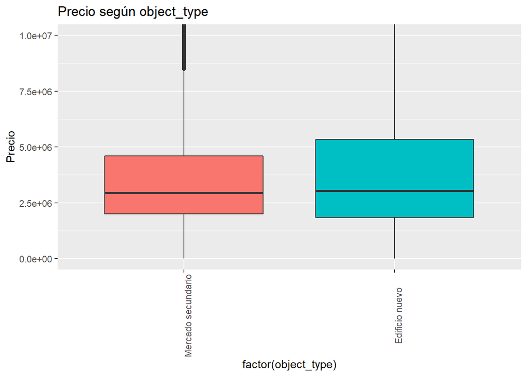

```r
grafico("object_type", 10000000)
```

A pesar de que en la Tabla 1 los Edificios nuevos parecían tener una media de precios menor que los de segunda mano, en este gráfico observamos que no existen diferencias considerables, siendo incluso ligeramente mayores los de los Edificios nuevos. Probablemente las diferencias en la tabla sean debidas a los valores outlier.

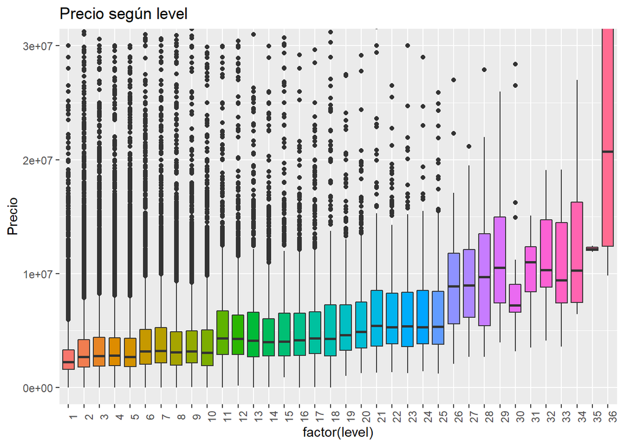

```r
grafico("level", 30000000)
```

Parece que la media de precios aumenta de precios aumenta de forma más o menos constante a medida que aumenta la altura del apartamento en venta.

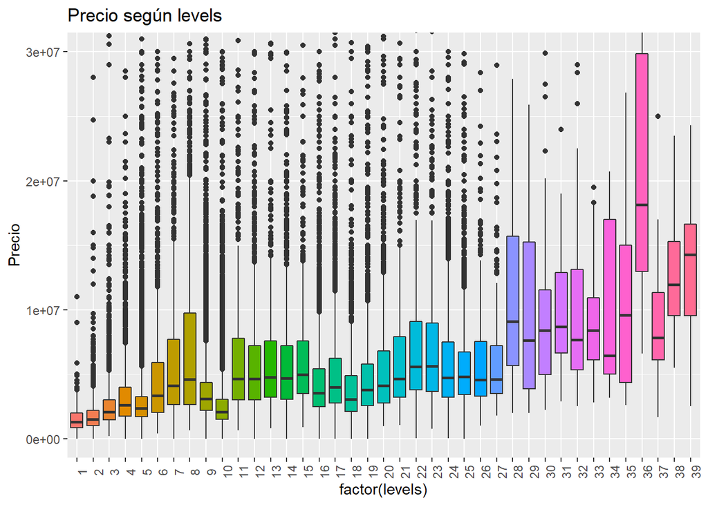

```r
grafico("levels",30000000)
```

De forma similar a la anterior, el precio aumenta a medida que aumenta el número de plantas del inmueble, excepto para los que tienen 9 y 10 plantas. Esto podría estar influenciado por la mayor frecuencia de este tipo de inmuebles.

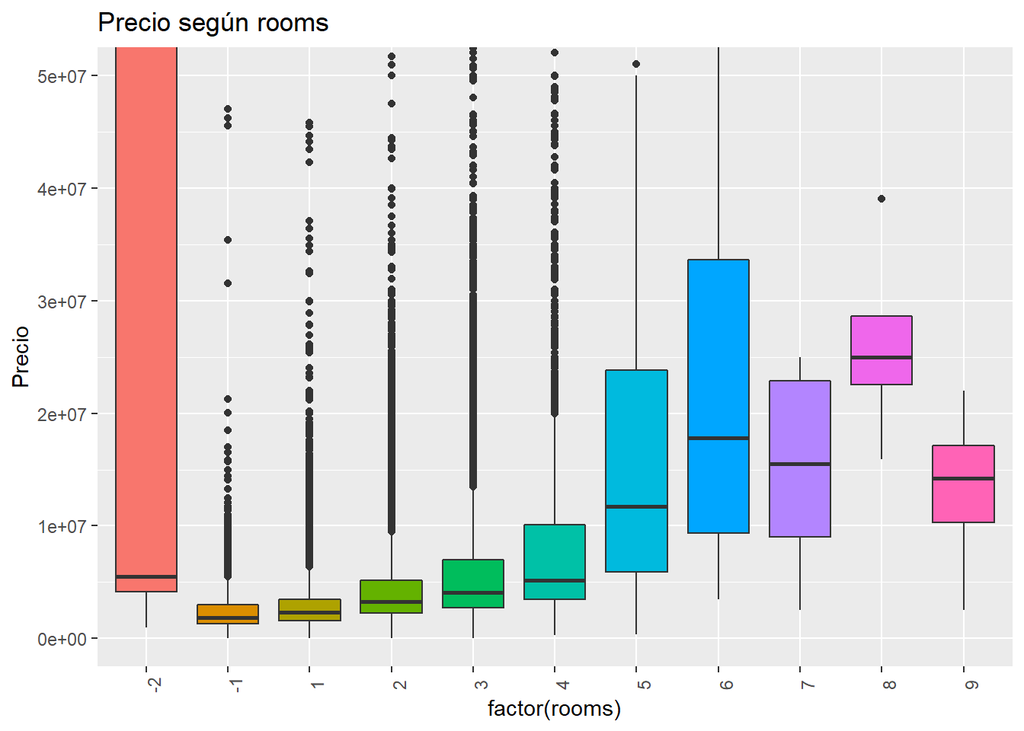

```r
grafico("rooms",50000000)
```

Vemos que los apartamentos con el dato erróneo de -2 habitaciones distorsionan bastante la variable precio. Para el resto, observamos que el precio va aumentando a medida que aumenta el número de habitaciones, excepto cuándo tienen 7 y 9 habitaciones, que disminuye ligeramente.

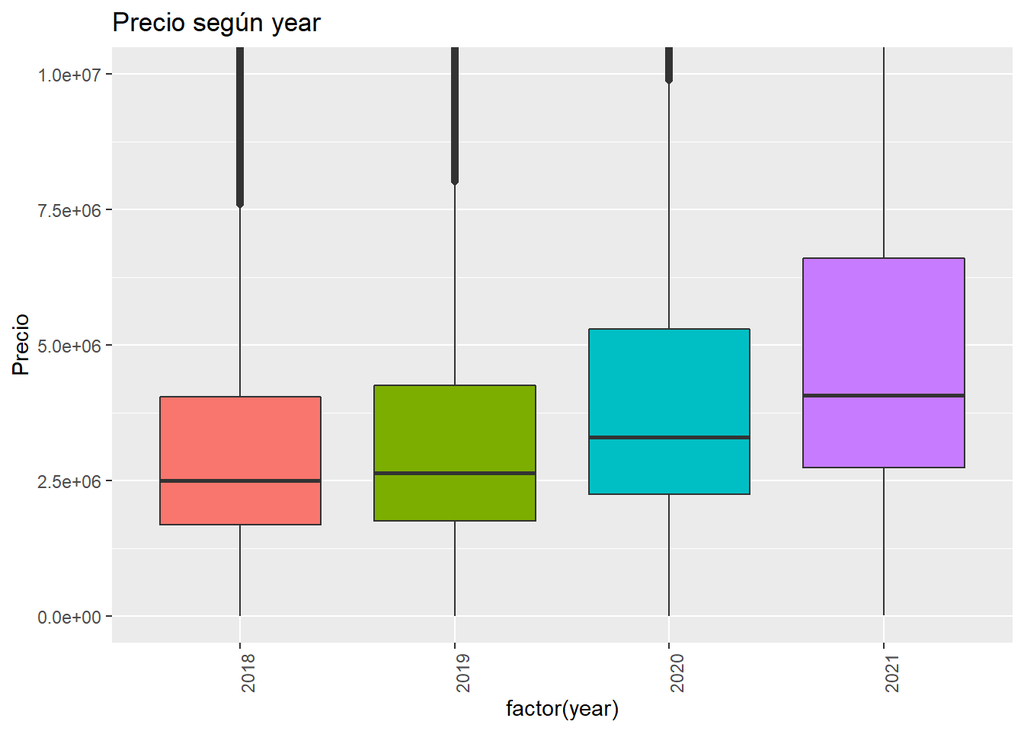

```r
suppressPackageStartupMessages(library(lubridate))
#Creamos una variable temporal "year" para ver la evolución temporal
datos$year <- year(datos$date)
datos$year <- as.factor(datos$year)

grafico("year",10000000)
```

Vemos que la media de precios ha aumentado a lo largo del tiempo, sobre todo desde 2019 hasta 2021.

```r
#Eliminamos la variable temporal
datos$year <- NULL
```

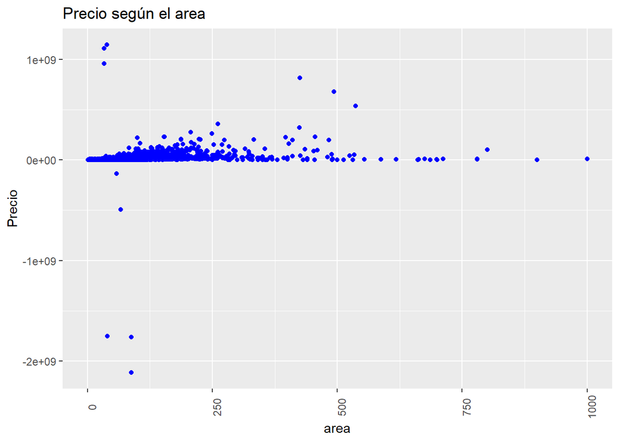

```r
ggplot(datos, aes(x=area, y = price)) +
  geom_point(color = "blue") +
  coord_cartesian(xlim = c(0,1000)) +
  ylab("Precio") +
  theme(axis.text.x = element_text(angle = 90)) +
  ggtitle(paste0("Precio según el area")) +
  theme(legend.position = "none")
```

Debido a los valores outliers del area, hemos acortado la coordenada *x* de forma que el gráfico sea más visual. Vemos de nuevo los distintos valores outlier en la variable precio. No se ve claramente, pero parece que el precio va aumentando a medida que aumenta el area total de los inmuebles.

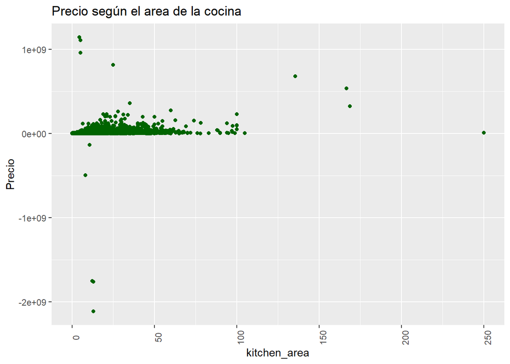

```r
ggplot(datos, aes(x=kitchen_area, y = price)) +
  geom_point(color= "darkgreen") +
  coord_cartesian(xlim = c(0,250)) +
  ylab("Precio") +
  theme(axis.text.x = element_text(angle = 90)) +
  ggtitle(paste0("Precio según el area de la cocina")) +
  theme(legend.position = "none")
```

A diferencia del area total, parece que el precio aumenta según el area de la cocina hasta los 25m$^2$ apróximadamente, y a partir de ahí disminuye de nuevo.

```r
suppressPackageStartupMessages(library(mapdata))
suppressPackageStartupMessages(library(maps))
suppressPackageStartupMessages(library(ggrepel))
suppressPackageStartupMessages(library(tidyverse))

mapa_mundo <- map_data("world")
```

Vamos a realizar un mapa para ver si hay diferencias de precios según la ubicación del inmueble.

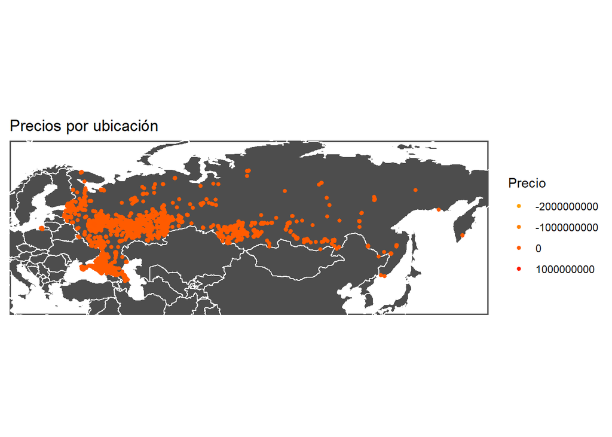

```r
options(scipen= 999)

mapa_mundo %>%
  ggplot() +
  geom_polygon(aes(x=long, y=lat, group=group),
               fill= "grey30", color="white") +
  geom_point(data=datos, aes(x=geo_lon, y=geo_lat, color= price), stroke=F) +
  coord_fixed(xlim= c(17,160),
              ylim= c(35,75),
              ratio = 1.3)+
  ggtitle("Precios por ubicación") +
  scale_size_continuous(name = "Precio") +
  scale_color_gradient(low= "orange", high= "red", name= "Precio") +
  guides(color= guide_legend()) +
  theme_classic() +
  theme(
    axis.line = element_blank(),
    axis.text = element_blank(),
    axis.title = element_blank(),
    axis.ticks = element_blank(),
    panel.background = element_rect(colour= "grey30", size= 1, fill= NA)
  )
```

Como es lógico, vemos que la mayor parte se encuentran en las zonas más habitadas de Rusia, al oeste del país (Moscú, San Petersburgo y Volga).

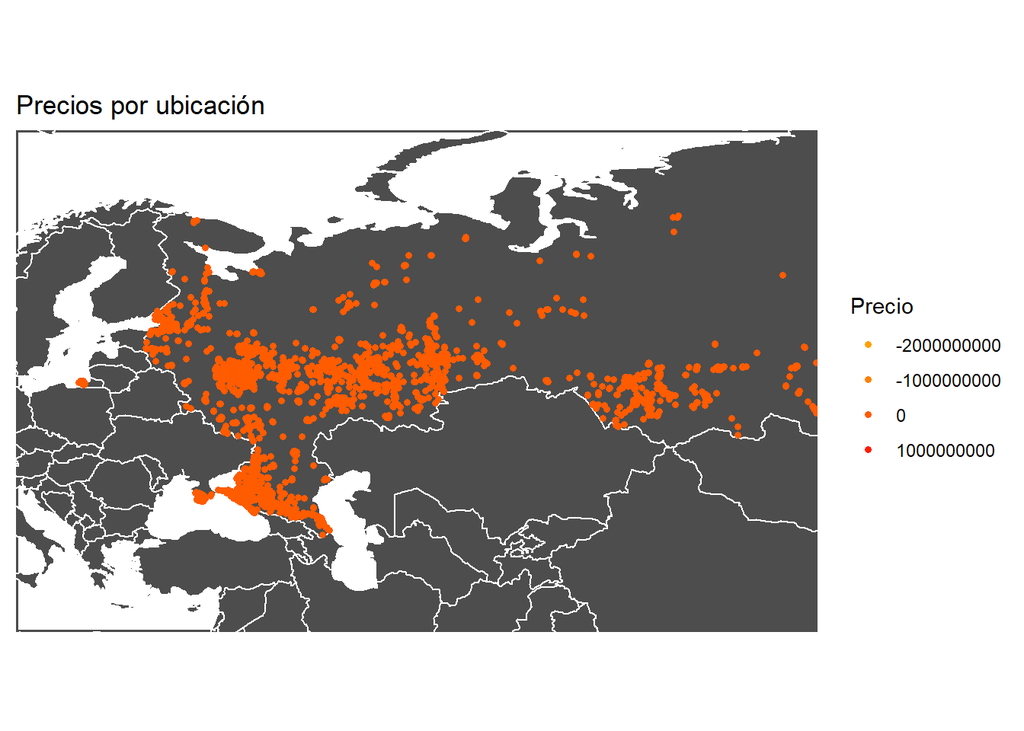

```r
options(scipen= 999)

mapa_mundo %>%
  ggplot() +
  geom_polygon(aes(x=long, y=lat, group=group),
               fill= "grey30", color="white") +
  geom_point(data=datos, aes(x=geo_lon, y=geo_lat, color= price), stroke=F) +
  coord_fixed(xlim= c(17,100),
              ylim= c(35,75),
              ratio = 1.3)+
  ggtitle("Precios por ubicación") +
  scale_size_continuous(name = "Precio") +
  scale_color_gradient(low= "orange", high= "red", name= "Precio") +
  guides(color= guide_legend()) +
  theme_classic() +
  theme(
    axis.line = element_blank(),
    axis.text = element_blank(),
    axis.title = element_blank(),
    axis.ticks = element_blank(),
    panel.background = element_rect(colour= "grey30", size= 1, fill= NA)
  )
```

Enfocando en esas zonas, se ve con mayor claridad su distribución. Vemos que también hay gran cantidad de inmuebles en las zonas cercanas a Georgia y Ucrania, y también en Crimea.

No podemos ver con claridad las diferencias de precio por zonas debido a la gran cantidad de valores outliers en la variable precio.

### 2. Tabla de correlaciones

```r
#Transformamos las variables en numéricas
datos$level <- as.numeric(datos$level)
datos$levels <- as.numeric(datos$levels)
datos$rooms <- as.numeric (as.character(datos$rooms))

#Realizamos la tabla con las variables explicativas numéricas
correlaciones <- round(cor(datos[,c(4:5,8:10,11:12)]))
correlaciones
```

```
##              geo_lat geo_lon level levels rooms area kitchen_area
## geo_lat            1       0     0      0     0    0            0
## geo_lon            0       1     0      0     0    0            0
## level              0       0     1      1     0    0            0
## levels             0       0     1      1     0    0            0
## rooms              0       0     0      0     1    0            0
## area               0       0     0      0     0    1            0
## kitchen_area       0       0     0      0     0    0            1
```

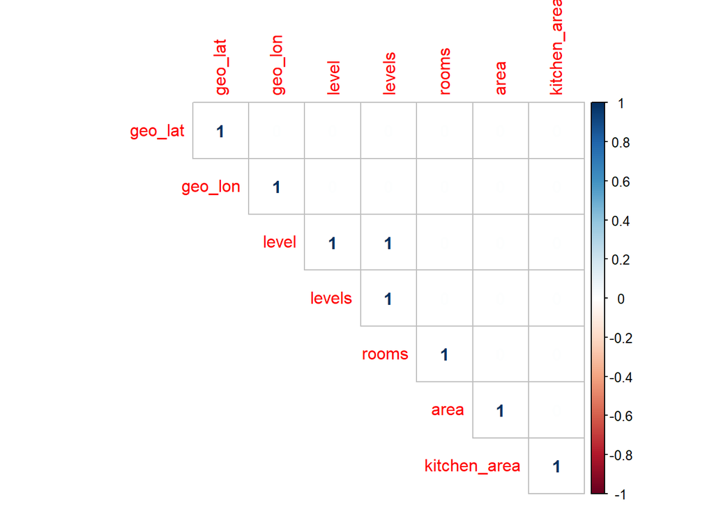

```r
suppressPackageStartupMessages(library(corrplot))
corrplot(correlaciones, method = "number", type = "upper")
```

### 3. Análisis valores ausentes y extremos

La imputación de valores ausentes no es necesaria, ya que como comprobamos previamente no había dichos valores.

En los gráficos anteriores sí que vimos la existencia de una gran cantidad de valores atípicos. Siguiendo las indicaciones del anexo, vamos a analizar la existencia de outliers y su posible eliminación.

```r
datos %>% count(kitchen_area < 2)
```

```
##   kitchen_area < 2     n
## 1            FALSE 82012
## 2             TRUE   341
```

Los registros con una cocina de menos de 2m$^2$ son posibles valores outliers, debido a que no sería coherente tener una cocina con un area menor. Observamos que nuestro dataset tiene 341 registros con dicha característica, por tanto procedemos a eliminarlos.

```r
datosOK <- datos[!(datos$kitchen_area < 2),]
```

```r
datos_pisos <- datosOK %>% mutate(area_aprox = (rooms*9 + 12 + 6 + kitchen_area)*1.10) %>% filter(rooms != -1 & area >= area_aprox -10 & area <= area_aprox +10)
head(datos_pisos)
```

```
##     price       date     time  geo_lat  geo_lon region building_type level
## 1 1750000 2019-11-13 13:01:13 46.67828 38.29166   2843      Ladrillo     3
## 2 8498000 2020-02-10 12:47:05 55.60561 37.58216      3         Panel     2
## 3 5100000 2019-09-14 08:24:07 56.72628 37.15074     81      Ladrillo     1
## 4 9151965 2021-04-24 12:52:30 55.86646 37.39378     81    Monolítico     4
## 5 1669676 2018-12-24 11:13:35 55.01767 83.00352   9654         Panel     2
## 6 2150000 2020-06-21 16:56:45 55.37824 39.05101     81          Otro    13
##   levels rooms  area kitchen_area        object_type     id dataset area_aprox
## 1      5     1 33.00        10.00 Mercado secundario 212238   train     40.700
## 2      9     3 50.00         9.00 Mercado secundario 193894   train     59.400
## 3      9     2 57.00        11.00 Mercado secundario 106354   train     51.700
## 4     10     2 57.00        10.20     Edificio nuevo  48461   train     50.820
## 5     10     3 59.02         8.51     Edificio nuevo 228556   train     58.861
## 6     14     1 41.88         8.84 Mercado secundario 102421   train     39.424
```

```r
datos_estudios <- datosOK %>% mutate(area_aprox = (9 + 6 + kitchen_area)*1.05) %>% filter(rooms == -1 & area >= area_aprox -5 & area <= area_aprox +5)
head(datos_estudios)
```

```
##     price       date     time  geo_lat  geo_lon region building_type level
## 1 1380000 2019-11-06 15:18:18 45.04203 39.02460   2843      Ladrillo     2
## 2 1544000 2019-09-24 21:21:16 60.07142 30.34259   2661    Monolítico    10
## 3 4821120 2021-05-01 10:15:47 55.52041 37.59666     81         Panel    13
## 4 1400000 2020-03-05 15:41:44 56.11307 47.20559   3019         Panel     7
## 5 1700000 2021-04-28 19:42:15 45.07323 38.90548   2843    Monolítico     2
## 6 1726600 2020-11-30 09:12:32 56.78011 60.69935   6171    Monolítico     3
##   levels rooms area kitchen_area        object_type     id dataset area_aprox
## 1      4    -1 25.2          6.0 Mercado secundario 204648   train      22.05
## 2     20    -1 22.8          5.0     Edificio nuevo  69771   train      21.00
## 3     15    -1 28.0          7.4     Edificio nuevo  75521   train      23.52
## 4     10    -1 25.1          5.0 Mercado secundario  18485   train      21.00
## 5     18    -1 23.0          5.0 Mercado secundario 216462   train      21.00
## 6     25    -1 22.3          5.0     Edificio nuevo  93770   train      21.00
```

```r
datosOK <- bind_rows(datos_pisos,datos_estudios)
```

Hemos calculado el area apróximada que deberían tener los inmuebles según sus carácterísticas, siguiendo lo datos de anexo. Hemos comparado el area apróximada con el area del dataset, dando un margen de 10m$^2$ para los pisos y 5m$^2$ para los estudios, y eliminando los que no estuviesen dentro del umbral.

Recordamos que había inmuebles con -2 habitaciones, lo cual parecía erróneo, por lo que vamos eliminar dichos registros.

```r
datosOK %>% filter(rooms == -2)
```

```
##     price       date     time  geo_lat  geo_lon region building_type level
## 1 1000000 2021-01-28 09:02:46 45.19371 36.99803   2843        Blocky     2
##   levels rooms area kitchen_area    object_type    id dataset area_aprox
## 1      2    -2    9            4 Edificio nuevo 69377   train        4.4
```

Vemos que ya solo había uno.

```r
datosOK <- datosOK[!(datosOK$rooms == -2),]
```

También habíamos visto una gran cantidad de outliers en la variable precio. Vamos a evaluar el precio por m$^2$, teniendo en cuenta que en Rusia el precio medio por m$^2$ es de entre 63.000 - 90.000 rublos.

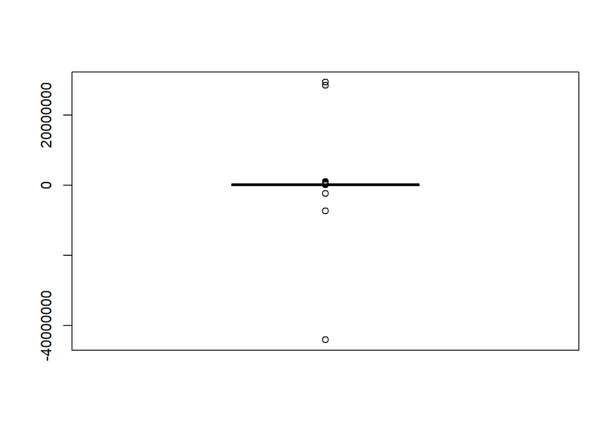

```r
datosOK <- datosOK %>% mutate(price_m2 = price/area)
boxplot_pricem2 <- boxplot(datosOK$price_m2)
```

Vemos de nuevo que existen varios outliers en el precio por metro cuadrado, haciendo incluso que sea practicamente imposible ver la media de precios correctamente.

```r
outliers <- boxplot_pricem2$out
str(outliers)
```

```
##  num [1:4415] 169960 160561 211823 201316 209500 ...
```

Observamos que el boxplot nos indica que hay 4415 valores outliers para la variable precio por m$^2$. Por tanto, vamos a eliminar dichos outliers.

```r
datosOK <- datosOK[-which(datosOK$price_m2 %in% outliers),]
```

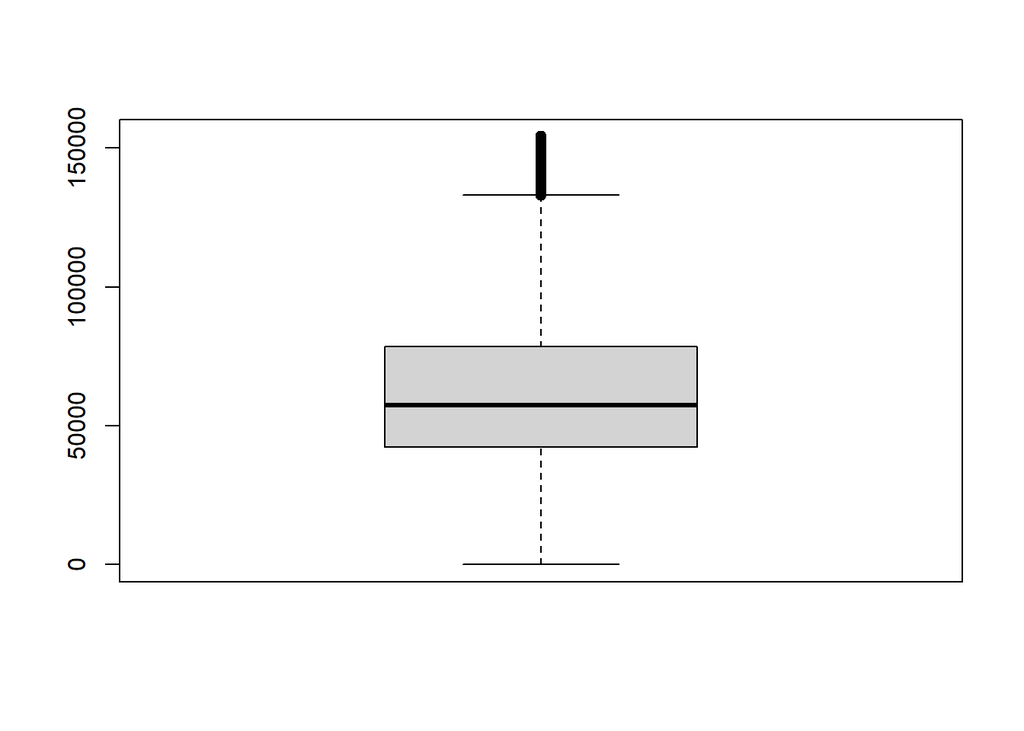

```r
boxplot(datosOK$price_m2)
```

```r
mean(datosOK$price_m2)
```

```
## [1] 63616.3
```

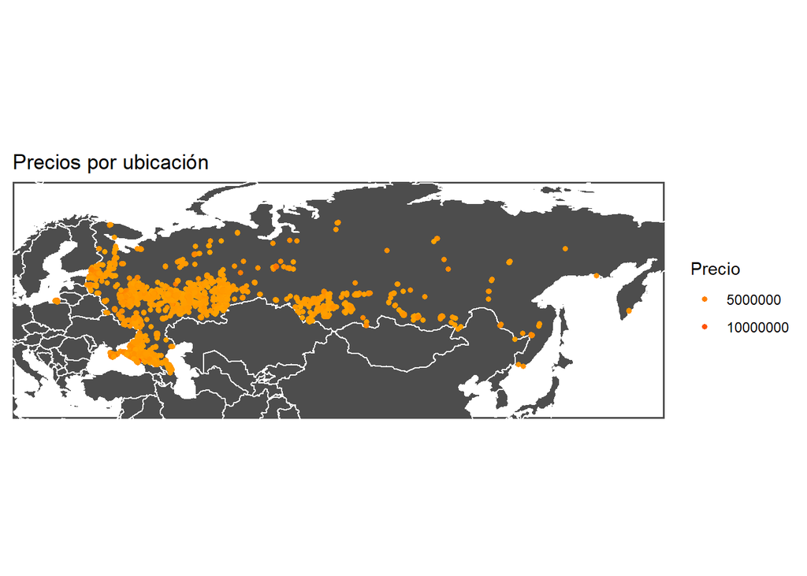

```r
options(scipen= 999)

mapa_mundo %>%
  ggplot() +
  geom_polygon(aes(x=long, y=lat, group=group),
               fill= "grey30", color="white") +
  geom_point(data=datosOK, aes(x=geo_lon, y=geo_lat, color= price), stroke=F) +
  coord_fixed(xlim= c(17,160),
              ylim= c(35,75),
              ratio = 1.3)+
  ggtitle("Precios por ubicación") +
  scale_size_continuous(name = "Precio") +
  scale_color_gradient(low= "orange", high= "red", name= "Precio") +
  guides(color= guide_legend()) +
  theme_classic() +
  theme(
    axis.line = element_blank(),
    axis.text = element_blank(),
    axis.title = element_blank(),
    axis.ticks = element_blank(),
    panel.background = element_rect(colour= "grey30", size= 1, fill= NA)
  )
```

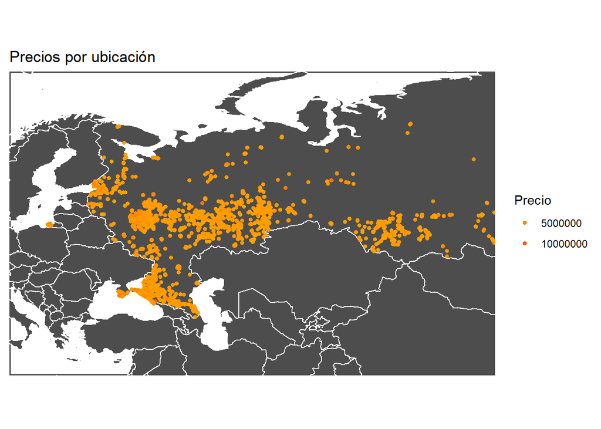

```r
options(scipen= 999)

mapa_mundo %>%
  ggplot() +
  geom_polygon(aes(x=long, y=lat, group=group),
               fill= "grey30", color="white") +
  geom_point(data=datosOK, aes(x=geo_lon, y=geo_lat, color= price), stroke=F) +
  coord_fixed(xlim= c(17,100),
              ylim= c(35,75),
              ratio = 1.3)+
  ggtitle("Precios por ubicación") +
  scale_size_continuous(name = "Precio") +
  scale_color_gradient(low= "orange", high= "red", name= "Precio") +
  guides(color= guide_legend()) +
  theme_classic() +
  theme(
    axis.line = element_blank(),
    axis.text = element_blank(),
    axis.title = element_blank(),
    axis.ticks = element_blank(),
    panel.background = element_rect(colour= "grey30", size= 1, fill= NA)
  )
```

Podemos ver de nuevo la ubicación de los inmuebles de nuestro nuevo dataset en los mapas. Vemos que se ha reducido el número de inmuebles, y el cambio de color según el precio.

En principio no se aprecia una diferencia clara en los precios según la ubicación, ya que en la mayoría de regiones se encuentran alrededor de 5.000.000 rublos y alguno excepcional de 10.000.000.

```r
correlaciones <- round(cor(datosOK[,c(4:5,8:12)]))
correlaciones
```

```
##              geo_lat geo_lon level levels rooms area kitchen_area
## geo_lat            1       0     0      0     0    0            0
## geo_lon            0       1     0      0     0    0            0
## level              0       0     1      1     0    0            0
## levels             0       0     1      1     0    0            0
## rooms              0       0     0      0     1    1            0
## area               0       0     0      0     1    1            0
## kitchen_area       0       0     0      0     0    0            1
```

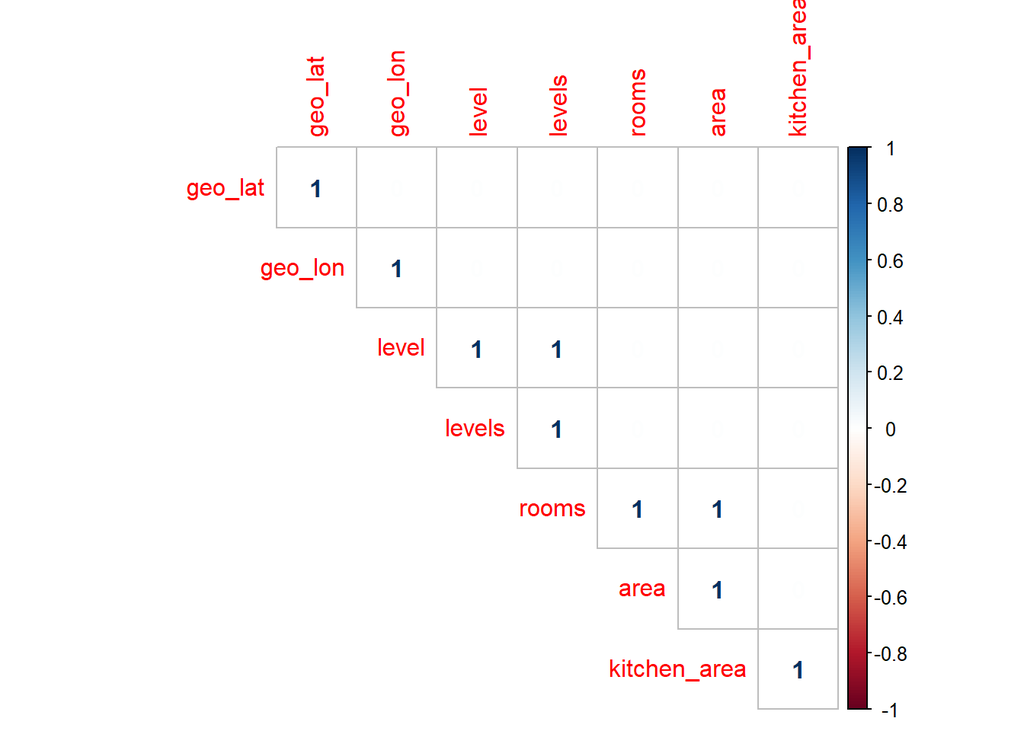

```r
suppressPackageStartupMessages(library(corrplot))
corrplot(correlaciones, method = "number", type = "upper")
```

### 4. Selección de variables

Tras el análisis de correlaciones, sería conveniente eliminar algunas de las variables con correlación alta, para evitar problemas de multicolinealidad.  
Decidimos eliminar *levels* y *area*.

También serían prescindibles la variable *id* y las creadas por nosotros *area_aprox* y *precio_m2*, ya que son cálculos de otras variables y también provocarían multicolinealidad.  
Al tener la variable *fecha* también vamos a prenscindir de la varible *time*, ya que no parece aportar información relevante.

```r
datosOK <- datosOK[,-c(3,9,11,14,16:17)]
```

Convertimos de nuevo las variables *level* y *rooms* en factor para la modelización.

```r
datosOK$level <- as.factor(datosOK$level)
datosOK$rooms <- as.factor(datosOK$rooms)
str(datosOK)
```

```
## 'data.frame':    53716 obs. of  11 variables:
##  $ price        : num  1750000 5100000 1669676 2150000 1416000 ...
##  $ date         : Date, format: "2019-11-13" "2019-09-14" ...
##  $ geo_lat      : num  46.7 56.7 55 55.4 55 ...
##  $ geo_lon      : num  38.3 37.2 83 39.1 83 ...
##  $ region       : Factor w/ 82 levels "3","69","81",..: 18 3 70 3 70 14 7 1 29 44 ...
##  $ building_type: Factor w/ 6 levels "Otro","Panel",..: 4 4 2 1 2 3 4 3 3 4 ...
##  $ level        : Factor w/ 33 levels "1","2","3","4",..: 3 1 2 13 2 3 7 2 4 10 ...
##  $ rooms        : Factor w/ 8 levels "-1","1","2","3",..: 2 3 4 2 2 3 2 3 2 2 ...
##  $ kitchen_area : num  10 11 8.51 8.84 13.78 ...
##  $ object_type  : Factor w/ 2 levels "Mercado secundario",..: 1 1 2 1 2 2 2 2 2 1 ...
##  $ dataset      : Factor w/ 2 levels "test","train": 2 2 2 2 2 2 2 2 2 2 ...
```

Podríamos utilizar también otros métodos de selección de varibles, como simulated annealing, pero se ha decidido no hacerlo debido a que es computacionalmente costoso.

## Modelización

### Partición de Datos

```r
train <- datosOK %>% filter(dataset == "train")
test <- datosOK %>% filter(dataset == "test")

#Eliminamos la columna dataset

train$dataset <- NULL
test$dataset <- NULL
```

```r
summary(train)
```

```
##      price               date               geo_lat         geo_lon
##  Min.   :     400   Min.   :2018-09-08   Min.   :41.46   Min.   : 19.95
##  1st Qu.: 1800000   1st Qu.:2019-02-28   1st Qu.:53.19   1st Qu.: 38.78
##  Median : 2590000   Median :2019-10-05   Median :55.08   Median : 47.20
##  Mean   : 2946030   Mean   :2019-11-10   Mean   :53.87   Mean   : 54.28
##  3rd Qu.: 3650000   3rd Qu.:2020-07-03   3rd Qu.:56.30   3rd Qu.: 72.62
##  Max.   :14200000   Max.   :2021-05-01   Max.   :69.50   Max.   :158.70
##
##      region         building_type       level           rooms
##  9654   : 9197   Otro      : 2479   2      : 6813   1      :23988
##  2843   : 6228   Panel     :19058   1      : 6643   2      :17336
##  81     : 5070   Monolítico: 8330   3      : 5862   3      : 6973
##  2661   : 3455   Ladrillo  :18032   5      : 5758   -1     :  807
##  6171   : 2452   Blocky    : 1782   4      : 5347   4      :  690
##  2922   : 2390   Madera    :  133   6      : 2805   5      :   19
##  (Other):21022                      (Other):16586   (Other):    1
##   kitchen_area               object_type
##  Min.   : 2.00   Mercado secundario:36999
##  1st Qu.: 7.00   Edificio nuevo    :12815
##  Median : 9.00
##  Mean   : 9.64
##  3rd Qu.:11.10
##  Max.   :90.00
##
```

```r
summary(test)
```

```
##      price               date               geo_lat         geo_lon
##  Min.   :    1500   Min.   :2018-09-09   Min.   :42.05   Min.   : 20.38
##  1st Qu.: 1800000   1st Qu.:2019-03-03   1st Qu.:52.55   1st Qu.: 38.44
##  Median : 2600000   Median :2019-10-08   Median :55.06   Median : 45.03
##  Mean   : 2935352   Mean   :2019-11-11   Mean   :53.75   Mean   : 53.96
##  3rd Qu.: 3650000   3rd Qu.:2020-07-03   3rd Qu.:56.29   3rd Qu.: 65.61
##  Max.   :13800000   Max.   :2021-05-01   Max.   :67.51   Max.   :137.00
##
##      region        building_type      level          rooms       kitchen_area
##  9654   : 693   Otro      : 192   1      : 555   1      :1839   Min.   : 2.00
##  2843   : 521   Panel     :1478   2      : 510   2      :1413   1st Qu.: 6.90
##  81     : 402   Monolítico: 656   3      : 448   3      : 521   Median : 9.00
##  2661   : 289   Ladrillo  :1437   5      : 441   -1     :  68   Mean   : 9.55
##  6171   : 201   Blocky    : 132   4      : 440   4      :  58   3rd Qu.:11.00
##  3230   : 194   Madera    :   7   6      : 213   5      :   2   Max.   :45.10
##  (Other):1602                     (Other):1295   (Other):   1
##              object_type
##  Mercado secundario:2919
##  Edificio nuevo    : 983
##
##
##
##
##
```

Vemos que las distribuciones de las variables son similares en ambos datasets.

### Entrenamiento

```r
#Configuración del entrenamiento
suppressPackageStartupMessages(library(caret))
suppressPackageStartupMessages(library(parallel))
suppressPackageStartupMessages(library(doParallel))
control <- trainControl(method = "repeatedcv", number = 2, repeats = 4, verboseIter = FALSE)
control_oob <- trainControl(method = "oob", verboseIter = FALSE)
```

*Nota: Dada la baja capacidad computacional del equipo disponible, no se buscará el mejor parámetro tuneGrid para cada modelo, sino que directamente se indicará uno que se considere adecuado teniendo en cuenta ejercicios previos. Si no, implicaría demasiado tiempo de ejecución en cada modelo*

#### Árboles de decisión

##### Random Forest

```r
# Control para hacer o no hacer el entrenamiento del modelo
entrena <- 0

if(entrena == 1){

   set.seed(9)
rfGrid <-  expand.grid(mtry = 4) #Podría probarse con varios mtry = c(2,4,6,10) y después hacerlo con el que mejor predice. Es el número de variables utilizadas para la construcción de árboles.

   clusterCPU <- makePSOCKcluster(detectCores()-1)
   registerDoParallel(clusterCPU)
   system.time(modelo_rf <- train( price~., train, allowParallel=TRUE, method = "rf", metric = "RMSE", preProc = c("center", "scale"),trControl = control_oob, tuneGrid = rfGrid))
   stopCluster(clusterCPU)
   clusterCPU <- NULL

   saveRDS(modelo_rf, "modelo_rf.rds")
}

# Si no entreno, cargo modelo ya entrenado
if(entrena==0){
   modelo_rf <- readRDS("C:/Users/Usuario/Documents/Master BI/M5 - Minería de Datos I/Evaluación M5/modelo_rf.rds")
}
modelo_rf
```

```
## Random Forest
##
## 49814 samples
##     9 predictor
##
## Pre-processing: centered (130), scaled (130)
## Resampling results:
##
##   RMSE     Rsquared
##   1081068  0.5389245
##
## Tuning parameter 'mtry' was held constant at a value of 4
```

```r
var_imp_rf <- varImp(modelo_rf)

var_imp_rf
```

```
## rf variable importance
##
##   only 20 most important variables shown (out of 130)
##
##                           Overall
## geo_lon                   100.000
## kitchen_area               56.452
## geo_lat                    55.622
## region2661                 51.077
## rooms1                     30.837
## building_typeMonolítico    20.340
## region81                   17.276
## rooms3                     14.102
## date                       13.155
## rooms2                     11.441
## region9654                  8.764
## object_typeEdificio nuevo   7.527
## building_typePanel          7.397
## region5282                  6.918
## building_typeLadrillo       5.521
## region2843                  2.949
## region2604                  2.237
## rooms4                      2.229
## region6817                  1.969
## region3019                  1.716
```

Observamos que el RMSE obtenido en el modelo es bastante alto, y que el $R^2$ es de un 0.538, es decir que el modelo se ajustaría un 53.8%. Es un ajuste bastante bajo.

Por otro lado, vemos que las variables de mayor importancia en este modelo son geo_lon, kitchen_area, geo_lat y el factor 2661 de la variable region.

*Nota: No realizamos gráfico dado que no es legible por la cantidad de factores*

```r
#Validación
prediccion_rf <- predict(modelo_rf,test)

R2_rf <- R2(prediccion_rf, test[,1])
RMSE_rf <- RMSE(prediccion_rf, test[,1])
MAE_rf <- MAE(prediccion_rf, test[,1])
```

#### Métodos de vecindad

##### K-vecinos

```r
entrena <- 0

if(entrena == 1){

   set.seed(9)
knnGrid <-  expand.grid(k = 20) #Podría probarse con varios k= c(10,30,40) y después hacerlo con el que mejor predice.

   clusterCPU <- makePSOCKcluster(detectCores()-1)
   registerDoParallel(clusterCPU)
   system.time(modelo_knn <- train( price~., train, allowParallel=TRUE, method = "knn", metric = "RMSE", preProc = c("center", "scale"),trControl = control, tuneGrid = knnGrid))
   stopCluster(clusterCPU)
   clusterCPU <- NULL

   saveRDS(modelo_knn, "modelo_knn.rds")
}


if(entrena==0){
   modelo_knn <- readRDS("C:/Users/Usuario/Documents/Master BI/M5 - Minería de Datos I/Evaluación M5/modelo_knn.rds")
}
modelo_knn
```

```
## k-Nearest Neighbors
##
## 49814 samples
##     9 predictor
##
## Pre-processing: centered (130), scaled (130)
## Resampling: Cross-Validated (5 fold, repeated 1 times)
## Summary of sample sizes: 39851, 39852, 39850, 39852, 39851
## Resampling results:
##
##   RMSE     Rsquared   MAE
##   1026980  0.5898345  729636.2
##
## Tuning parameter 'k' was held constant at a value of 20
```

```r
var_imp_knn <- varImp(modelo_knn)

ggplot(var_imp_knn)
```

[output not shown]

Con el método de K-vecinos, obtenemos un RMSE similar al anterior, y un $R^2$ de 0.589 que es ligeramente mejor.

Las variables a las que mayor importancia da son prácticamente las mismas que el algoritmo Random Forest, pero dando esta vez mayor importancia a la variable region, seguida de nuevo por kitchen_area, geo_lon y geo_lat.

```r
#Validación
prediccion_knn <- predict(modelo_knn,test)

R2_knn <- R2(prediccion_knn, test[,1])
RMSE_knn <- RMSE(prediccion_knn, test[,1])
MAE_knn <- MAE(prediccion_knn, test[,1])
```

#### Redes Neuronales

##### Perceptron Multicapa

```r
entrena <- 0

if(entrena == 1){

   set.seed(9)
mlpGrid <-  expand.grid(size = 3) #Podría probarse con varios size= c(3,6,8). Size es el número de capas ocultas.

   clusterCPU <- makePSOCKcluster(detectCores()-1)
   registerDoParallel(clusterCPU)
   system.time(modelo_mlp <- train( price~., train, allowParallel=TRUE, method = "mlp", metric = "RMSE", preProc = c("center", "scale"),trControl = control, tuneGrid = mlpGrid))
   stopCluster(clusterCPU)
   clusterCPU <- NULL

   saveRDS(modelo_mlp, "modelo_mlp.rds")
}


if(entrena==0){
   modelo_mlp <- readRDS("C:/Users/Usuario/Documents/Master BI/M5 - Minería de Datos I/Evaluación M5/modelo_mlp.rds")
}
modelo_mlp
```

```
## Multi-Layer Perceptron
##
## 49814 samples
##     9 predictor
##
## Pre-processing: centered (130), scaled (130)
## Resampling: Cross-Validated (5 fold, repeated 1 times)
## Summary of sample sizes: 39851, 39852, 39850, 39852, 39851
## Resampling results:
##
##   RMSE     Rsquared    MAE
##   2114140  0.01737635  1592678
##
## Tuning parameter 'size' was held constant at a value of 3
```

```r
var_imp_mlp <- varImp(modelo_mlp)

ggplot(var_imp_mlp)
```

[output not shown]

Con el Perceptrón Multicapa, obtenemos un RMSE el doble de alto que el de los anteriores algoritmos, y un $R^2$ muy bajo 1.73%, lo que indica que el ajuste es prácticamente nulo y no predeciría correctamente.

La importacia de las variables es la misma que en K-vecinos, siendo region y area de la cocina las de mayor importancia.

```r
#Validación
prediccion_mlp <- predict(modelo_mlp,test)

R2_mlp <- R2(prediccion_mlp, test[,1])
RMSE_mlp <- RMSE(prediccion_mlp, test[,1])
MAE_mlp <- MAE(prediccion_mlp, test[,1])
```

##### Red Neuronal de Base Radial

```r
entrena <- 0

if(entrena == 1){

   set.seed(9)
rbfGrid <-  expand.grid(size = 3) #Podría probarse con varios size= c(3,6,8)y después hacerlo con el que mejor predice. Size es el número de capas ocultas.

   clusterCPU <- makePSOCKcluster(detectCores()-1)
   registerDoParallel(clusterCPU)
   system.time(modelo_rbf <- train( price~., train, allowParallel=TRUE, method = "rbf", metric = "RMSE", preProc = c("center", "scale"),trControl = control, tuneGrid = rbfGrid))
   stopCluster(clusterCPU)
   clusterCPU <- NULL

   saveRDS(modelo_rbf, "modelo_rbf.rds")
}


if(entrena==0){
   modelo_rbf <- readRDS("C:/Users/Usuario/Documents/Master BI/M5 - Minería de Datos I/Evaluación M5/modelo_rbf.rds")
}
modelo_rbf
```

```
## Radial Basis Function Network
##
## 49814 samples
##     9 predictor
##
## Pre-processing: centered (130), scaled (130)
## Resampling: Cross-Validated (2 fold, repeated 4 times)
## Summary of sample sizes: 24908, 24906, 24905, 24909, 24906, 24908, ...
## Resampling results:
##
##   RMSE     Rsquared  MAE
##   1594867  NaN       1213629
##
## Tuning parameter 'size' was held constant at a value of 3
```

```r
var_imp_rbf <- varImp(modelo_rbf)

ggplot(var_imp_rbf)
```

[output not shown]

En este caso el RMSE vuelve a ser muy alto, y no hemos podido obtener el $R^2$.

Las variables más importantes vemos que son las mismas que las de los anteriores modelos.

```r
#Validación
prediccion_rbf <- predict(modelo_rbf,test)

R2_rbf <- R2(prediccion_rbf, test[,1])
RMSE_rbf <- RMSE(prediccion_rbf, test[,1])
MAE_rbf <- MAE(prediccion_rbf, test[,1])
```

##### Red Neuronal

```r
entrena <- 0

if(entrena == 1){

   set.seed(9)
nnetGrid <-  expand.grid( .size= c(3), .decay=c(0.01) ) #Podría probarse con varios size= c(3,6,8) y también decay= c(0.1,0.01,0.5) y después hacerlo con el que mejor predice. Size es el número de capas ocultas y decay es el peso de descenso.

   clusterCPU <- makePSOCKcluster(detectCores()-1)
   registerDoParallel(clusterCPU)
   system.time(modelo_nnet <- train( price~., train, allowParallel=TRUE, method = "nnet", metric = "RMSE", preProc = c("center", "scale"),trControl = control, tuneGrid = nnetGrid, linout = TRUE, maxit = 50, skip = TRUE ))
   stopCluster(clusterCPU)
   clusterCPU <- NULL

   saveRDS(modelo_nnet, "modelo_nnet.rds")
}


if(entrena==0){
   modelo_nnet <- readRDS("C:/Users/Usuario/Documents/Master BI/M5 - Minería de Datos I/Evaluación M5/modelo_nnet.rds")
}
modelo_nnet
```

```
## Neural Network
##
## 49814 samples
##     9 predictor
##
## Pre-processing: centered (130), scaled (130)
## Resampling: Cross-Validated (2 fold, repeated 4 times)
## Summary of sample sizes: 24908, 24906, 24905, 24909, 24906, 24908, ...
## Resampling results:
##
##   RMSE     Rsquared   MAE
##   1033645  0.5850544  771973.6
##
## Tuning parameter 'size' was held constant at a value of 3
## Tuning
##  parameter 'decay' was held constant at a value of 0.01
```

```r
var_imp_nnet <- varImp(modelo_nnet)

var_imp_nnet
```

```
## nnet variable importance
##
##   only 20 most important variables shown (out of 130)
##
##                     Overall
## level9               100.00
## region2661            77.54
## region3019            73.50
## level21               71.86
## region1010            59.39
## level20               57.26
## region81              54.98
## region2860            54.64
## region2722            53.71
## geo_lat               49.16
## region5368            48.81
## level2                47.38
## region2072            47.06
## region9654            45.38
## level10               44.05
## region8509            43.25
## level16               43.17
## region4982            42.63
## level14               40.21
## building_typeBlocky   39.97
```

El método nnet parece que mejora el RMSE y el $R^2$ (58.5%), con respecto al Perceptrón Multicapa y a la Red de Base Radial.

Este método da mayor importancia a varios factores de la variable level (9 es el primero), y a varios de la variable region (2661 y 3019 principalmente).

```r
#Validación
prediccion_nnet <- predict(modelo_nnet,test)

R2_nnet <- R2(prediccion_nnet, test[,1])
RMSE_nnet <- RMSE(prediccion_nnet, test[,1])
MAE_nnet <- MAE(prediccion_nnet, test[,1])
```

#### Máquinas de Vector Soporte

```r
entrena <- 0

if(entrena == 1){

   set.seed(9)
svmGrid <-  NULL #aquí podriamos hacer combinaciones de C=(1,5,10,50) y sigma = c(0.01, 0.05, 0.001). Sigma es el valor kernel, y C es el peso que le damos a uno u otro componente para controlar el sobreaprendizaje.

   clusterCPU <- makePSOCKcluster(detectCores()-1)
   registerDoParallel(clusterCPU)
   system.time(modelo_svm <- train( price~., train, allowParallel=TRUE, method = "svmRadial", metric = "RMSE", preProc = c("center", "scale"),trControl = control, tuneGrid = NULL))
   stopCluster(clusterCPU)
   clusterCPU <- NULL

   saveRDS(modelo_svm, "modelo_svm.rds")
}


if(entrena==0){
   modelo_svm <- readRDS("C:/Users/Usuario/Documents/Master BI/M5 - Minería de Datos I/Evaluación M5/modelo_svm.rds")
}
modelo_svm
```

```
## Support Vector Machines with Radial Basis Function Kernel
##
## 49814 samples
##     9 predictor
##
## Pre-processing: centered (130), scaled (130)
## Resampling: Cross-Validated (5 fold, repeated 1 times)
## Summary of sample sizes: 39851, 39852, 39850, 39852, 39851
## Resampling results across tuning parameters:
##
##   C     RMSE     Rsquared   MAE
##   0.25  1631285  0.4041364  1163509
##   0.50  1631224  0.4041334  1163467
##   1.00  1631103  0.4041320  1163385
##
## Tuning parameter 'sigma' was held constant at a value of 0.01008179
## RMSE was used to select the optimal model using the smallest value.
## The final values used for the model were sigma = 0.01008179 and C = 1.
```

```r
var_imp_svm <- varImp(modelo_svm)

ggplot(var_imp_svm)
```

[output not shown]

Vemos que el modelo utilizó como parámetros sigma = 0.01008179 y C=1. En este caso C tiene un valor pequeño, por lo que puede que muchos datos de entrenamiento se predigan mal. El RMSE sigue teniendo un valor similar a los anteriores, y vemos que tiene un $R^2$ de 40.4%, menor que Random Forest y K-vecinos.

Las importancia de las variables continúa siendo la misma.

```r
#Validación
prediccion_svm <- predict(modelo_svm,test)

R2_svm <- R2(prediccion_svm, test[,1])
RMSE_svm <- RMSE(prediccion_svm, test[,1])
MAE_svm <- MAE(prediccion_svm, test[,1])
```

#### Multiclasificadores

##### Bagged CART

```r
entrena <- 1

if(entrena == 1){

   set.seed(9)
bagGrid <-  NULL #Este algoritmo no lleva parámetros

   clusterCPU <- makePSOCKcluster(detectCores()-1)
   registerDoParallel(clusterCPU)
   system.time(modelo_bag <- train( price~., train, allowParallel=TRUE, method = "treebag", metric = "RMSE", preProc = c("center", "scale"),trControl = control, tuneGrid = NULL))
   stopCluster(clusterCPU)
   clusterCPU <- NULL

   saveRDS(modelo_bag, "modelo_bag.rds")
}
if(entrena==0){
   modelo_bag <- readRDS("C:/Users/Usuario/Documents/Master BI/M5 - Minería de Datos I/Evaluación M5/modelo_bag.rds")
}
modelo_bag
```

```
## Bagged CART
##
## 49814 samples
##     9 predictor
##
## Pre-processing: centered (130), scaled (130)
## Resampling: Cross-Validated (2 fold, repeated 4 times)
## Summary of sample sizes: 24908, 24906, 24905, 24909, 24906, 24908, ...
## Resampling results:
##
##   RMSE     Rsquared   MAE
##   1105732  0.5187606  828328.3
```

```r
var_imp_bag <- varImp(modelo_bag)

var_imp_bag
```

```
## treebag variable importance
##
##   only 20 most important variables shown (out of 131)
##
##                            Overall
## kitchen_area              100.0000
## rooms1                     67.5747
## geo_lat                    64.4424
## geo_lon                    34.1552
## rooms3                     31.0838
## region2661                 20.7425
## date                       18.0226
## building_typeMonolítico    16.8514
## rooms2                     15.1250
## region8090                 13.0719
## building_typePanel         10.1604
## region2843                  8.6124
## object_typeEdificio nuevo   4.9393
## region3446                  2.8981
## region5282                  2.2749
## building_typeLadrillo       1.0172
## region2880                  0.9694
## region2922                  0.6580
## region69                    0.0000
## region5993                  0.0000
```

En el modelo Bagged CART vemos que el RMSE y el $R^2$ no han mejorado respecto a Random Forest y K-vecinos, manteniendose con un ajuste de entorno al 50%.

En cambio, en este caso se da más importancia a la variable Kitchen_area, seguida del factor 1 de rooms y de geo_lat.

```r
#Validación
prediccion_bag <- predict(modelo_bag,test)

R2_bag <- R2(prediccion_bag, test[,1])
RMSE_bag <- RMSE(prediccion_bag, test[,1])
MAE_bag <- MAE(prediccion_bag, test[,1])
```

#### Modelos adicionales

##### Regresión Lineal

```r
entrena <- 0

if(entrena == 1){

   set.seed(9)
lmGrid <-  NULL #se podría indicar el intercepto

   clusterCPU <- makePSOCKcluster(detectCores()-1)
   registerDoParallel(clusterCPU)
   system.time(modelo_lm <- train( price~., train, allowParallel=TRUE, method = "lm", metric = "RMSE", preProc = c("center", "scale"),trControl = control, tuneGrid = NULL))
   stopCluster(clusterCPU)
   clusterCPU <- NULL

   saveRDS(modelo_lm, "modelo_lm.rds")
}


if(entrena==0){
   modelo_lm <- readRDS("C:/Users/Usuario/Documents/Master BI/M5 - Minería de Datos I/Evaluación M5/modelo_lm.rds")
}
modelo_lm
```

```
## Linear Regression
##
## 49814 samples
##     9 predictor
##
## Pre-processing: centered (130), scaled (130)
## Resampling: Cross-Validated (2 fold, repeated 4 times)
## Summary of sample sizes: 24908, 24906, 24905, 24909, 24906, 24908, ...
## Resampling results:
##
##   RMSE      Rsquared   MAE
##   930625.4  0.6584934  690233
##
## Tuning parameter 'intercept' was held constant at a value of TRUE
```

```r
var_imp_lm <- varImp(modelo_lm)

var_imp_lm
```

```
## lm variable importance
##
##   only 20 most important variables shown (out of 129)
##
##              Overall
## kitchen_area  100.00
## region2604     72.92
## region2072     71.32
## region81       66.34
## region5952     65.12
## region3230     57.13
## date           56.83
## region2843     50.07
## rooms3         48.72
## region2900     46.53
## region7896     45.54
## region2871     44.82
## region5241     42.97
## rooms4         41.68
## region7793     40.65
## region2880     40.37
## region3019     39.68
## region9648     39.49
## region3446     38.53
## region5789     37.62
```

Con la Regresión Lineal, vemos que mejora el RMSE y el $R^2$ (65.84%).

En este caso la variable de mayor importancia es Kitchen_area de nuevo, pero parece que el peso para el resto de variables es más equilibrado, estando las 10 siguientes entre 72 y 45. Principalmente son varios factores de la variable region (2604 y 2072 sobre todo), y en este caso adquiere también cierto peso la variable date.

```r
#Validación
prediccion_lm <- predict(modelo_lm,test)
R2_lm <- R2(prediccion_lm, test[,1])
RMSE_lm <- RMSE(prediccion_lm, test[,1])
MAE_lm <- MAE(prediccion_lm, test[,1])
```

##### Regresión LASSO

```r
entrena <- 0

if(entrena == 1){

   set.seed(9)
lassoGrid <-  expand.grid(alpha = 1, lambda = 0) #con alpha=1 indicamos que realice una regresión Lasso, si fuese 0 haría Ridge. Lambda es el parámetro de regularización y su valor óptimo es con el que se minimiza el error de validación cruzada.

   clusterCPU <- makePSOCKcluster(detectCores()-1)
   registerDoParallel(clusterCPU)
   system.time(modelo_lasso <- train( price~., train, allowParallel=TRUE, method = "glmnet", metric = "RMSE", preProc = c("center", "scale"),trControl = control, tuneGrid = lassoGrid))
   stopCluster(clusterCPU)
   clusterCPU <- NULL

   saveRDS(modelo_lasso, "modelo_lasso.rds")
}


if(entrena==0){
   modelo_lasso <- readRDS("C:/Users/Usuario/Documents/Master BI/M5 - Minería de Datos I/Evaluación M5/modelo_lasso.rds")
}
modelo_lasso
```

```
## glmnet
##
## 49814 samples
##     9 predictor
##
## Pre-processing: centered (130), scaled (130)
## Resampling: Cross-Validated (5 fold, repeated 1 times)
## Summary of sample sizes: 39851, 39852, 39850, 39852, 39851
## Resampling results:
##
##   RMSE      Rsquared   MAE
##   928426.6  0.6599343  689952.1
##
## Tuning parameter 'alpha' was held constant at a value of 1
## Tuning
##  parameter 'lambda' was held constant at a value of 0
```

```r
var_imp_lasso <- varImp(modelo_lasso)

var_imp_lasso
```

```
## glmnet variable importance
##
##   only 20 most important variables shown (out of 130)
##
##              Overall
## geo_lon       100.00
## region2843     98.14
## region3230     60.54
## region81       40.48
## geo_lat        39.12
## rooms2         37.01
## rooms3         36.50
## region2900     34.12
## region2604     31.37
## region2072     29.23
## kitchen_area   28.58
## region5282     27.42
## region2922     26.01
## region5952     25.35
## region3106     24.43
## region2871     23.50
## region7896     22.04
## region3019     21.64
## region4007     21.46
## region2661     19.64
```

En este modelo vemos de nuevo una mejoría tanto del RMSE, como del $R^2$ (65.99%).

También llama la atención el cambio en la importancia de las variables, dejando de estar en los primeros puestos las variables kitchen_area y pasando a ser las más importantes geo_lon, y los factores 2843 y 3230 de region.

En los anteriores modelos, el factor 2661 de region, era de los que más peso tenía, mientras en este caso es de los que menos.

```r
#Validación
prediccion_lasso <- predict(modelo_lasso,test)

R2_lasso <- R2(prediccion_lasso, test[,1])
RMSE_lasso <- RMSE(prediccion_lasso, test[,1])
MAE_lasso <- MAE(prediccion_lasso, test[,1])
```

### Evaluación de modelos

#### Tabla comparativa de modelos

Vamos a crear una tabla comparativa de los resultados con los datos de test.

```r
suppressPackageStartupMessages(library(formattable))
suppressPackageStartupMessages(library(kableExtra))

resultados <- data.frame(
  modelo=c(modelo_rf$modelInfo$label,
           modelo_knn$modelInfo$label,
           modelo_mlp$modelInfo$label,
           modelo_rbf$modelInfo$label,
           modelo_nnet$modelInfo$label,
           modelo_svm$modelInfo$label,
           modelo_bag$modelInfo$label,
           modelo_lm$modelInfo$label,
           modelo_lasso$modelInfo$label),

  R2=round(c(R2_rf,
           R2_knn,
           R2_mlp,
           R2_rbf,
           R2_nnet,
           R2_svm,
           R2_bag,
           R2_lm,
           R2_lasso),digits=3),


  RMSE=round(c(RMSE_rf,
           RMSE_knn,
           RMSE_mlp,
           RMSE_rbf,
           RMSE_nnet,
           RMSE_svm,
           RMSE_bag,
           RMSE_lm,
           RMSE_lasso),digits=3),


  MAE=round(c(MAE_rf,
           MAE_knn,
           MAE_mlp,
           MAE_rbf,
           MAE_nnet,
           MAE_svm,
           MAE_bag,
           MAE_lm,
           MAE_lasso),digits=3))




resultados %>%
  mutate(
    modelo = modelo,
    R2 = color_tile("white", "orange")(R2),
    RMSE = color_tile("lightblue", "white")(RMSE),
    MAE = color_tile("hotpink", "white")(MAE)
  ) %>%
  select(modelo, everything()) %>%
  kable(escape = F) %>%
  kable_styling("hover", full_width = F) %>%
  add_header_above(c(" ", "Test" = 3))
```

| modelo | Test R2 | Test RMSE | Test MAE |
| --- | --- | --- | --- |
| Random Forest | 0.633 | 1036693.8 | 762333.4 |
| k-Nearest Neighbors | 0.611 | 973520.5 | 696273.6 |
| Multi-Layer Perceptron | 0.012 | 2491971.0 | 1924204.4 |
| Radial Basis Function Network | NA | 1565371.5 | 1224145.3 |
| Neural Network | 0.576 | 1014719.5 | 755967.6 |
| Support Vector Machines with Radial Basis Function Kernel | 0.425 | 1593620.4 | 1149930.5 |
| Bagged CART | 0.522 | 1076002.1 | 810286.8 |
| Linear Regression | 0.650 | 921922.1 | 685137.9 |
| glmnet | 0.650 | 921204.5 | 685111.0 |

En la tabla anterior vemos resaltados con un color más intenso las métricas de los modelos con mejores resultados.

Observamos que las que peor resultados obtinen son el Perceptrón Multicapa y la Red Neuronal de Base Radial, con unos RMSE muy altos (en el Perceptrón Multicapa es casi el doble que en el resto de modelos), y unos $R^2$ prácticamente nulos o no calculados.

Por otro lado observamos que los modelos con mejores RMSE y MAE, son K-vecinos, la Regresión Lineal, y la Regresión Lasso (glmnet). Mientras que los que obtienen un mejor $R^2$ son Random Forest y las regresiones Lineal y Lasso.

Por tanto, los modelos más adecuados serían la **Regresión Lineal** y la **Regresión Lasso**, siendo esta última ligeramente mejor, por tener un RMSE y un MAE un poco más bajos. Además, la **Regresión LASSO** no se ve influenciada por problemas de multicolinealidad y es útil cuando trabajamos con un gran número de variables, por tanto este sería el algoritmo que mejor predice.

Sin embargo, tampoco son modelos especialmente buenos, ya que tienen una capacidad de predicción del 65%, la cual no es demasiado alta, y los valores de RMSE y MAE siguen siendo excesivamente elevados.

#### Remuestreo

Para analizar y comparar los datos de lo que ha ocurrido durante el entrenamiento en los diferentes modelos, vamos a dividir los modelos en dos grupos. Esto es debido a que, por alguna razón, a pesar de utilizar el mismo parámetro de control (Cross-Validation) para todos los modelos, unos tienen 5 remuestreos y otros 8.

Como en Random Forest hemos utilizado el control Out-Of-Bag Error, lo quitamos de este análisis.

```r
remuestreos1 <- resamples(list(
           KNN=modelo_knn,
           MLP=modelo_mlp,
           SVM=modelo_svm,
           LASSO=modelo_lasso))
diferencias <- diff(remuestreos1)
summary(remuestreos1)
```

```
##
## Call:
## summary.resamples(object = remuestreos1)
##
## Models: KNN, MLP, SVM, LASSO
## Number of resamples: 5
##
## MAE
##            Min.   1st Qu.    Median      Mean   3rd Qu.      Max. NA's
## KNN    725467.5  727935.5  728473.7  729636.2  732718.3  733586.2    0
## MLP   1425479.0 1444167.3 1444735.3 1592678.3 1716275.6 1932734.2    0
## SVM   1154744.7 1157793.1 1161690.1 1163385.0 1165042.8 1177654.5    0
## LASSO  682407.0  684168.3  691583.8  689952.1  691633.0  699968.5    0
##
## RMSE
##            Min.   1st Qu.    Median      Mean   3rd Qu.      Max. NA's
## KNN   1017967.5 1024729.7 1026842.9 1026980.2 1030489.8 1034870.9    0
## MLP   1862348.9 1918685.6 1948497.2 2114140.0 2274497.5 2566670.8    0
## SVM   1614976.6 1620680.7 1630835.3 1631102.8 1631478.9 1657542.6    0
## LASSO  909811.4  923806.9  926836.5  928426.6  939885.9  941792.6    0
##
## Rsquared
##                 Min.      1st Qu.       Median       Mean     3rd Qu.
## KNN   0.578560589321 0.5865786892 0.5884445863 0.58983452 0.591018548
## MLP   0.000008431772 0.0004417439 0.0009031426 0.01737635 0.003865865
## SVM   0.385674855464 0.3973960864 0.4009317827 0.40413195 0.410071723
## LASSO 0.647595208355 0.6607538572 0.6609071379 0.65993431 0.663073008
##             Max. NA's
## KNN   0.60457020    0
## MLP   0.08166255    0
## SVM   0.42658533    0
## LASSO 0.66734231    0
```

```r
remuestreos2 <- resamples(list(
           RBF=modelo_rbf,
           NNET=modelo_nnet,
           BAG=modelo_bag,
           LM=modelo_lm))
#diferencias2 <- diff(remuestreos2)
summary(remuestreos2)
```

```
##
## Call:
## summary.resamples(object = remuestreos2)
##
## Models: RBF, NNET, BAG, LM
## Number of resamples: 8
##
## MAE
##           Min.   1st Qu.    Median      Mean   3rd Qu.      Max. NA's
## RBF  1193334.3 1195701.7 1212135.7 1213629.3 1230566.4 1238626.7    0
## NNET  703621.1  710239.1  746992.8  771973.6  839531.7  869751.2    0
## BAG   821901.2  823561.3  826192.5  828328.3  831685.8  839747.5    0
## LM    687809.6  689484.8  689889.8  690233.0  691110.0  692684.0    0
##
## RMSE
##           Min.   1st Qu.    Median      Mean   3rd Qu.      Max. NA's
## RBF  1583838.2 1591309.0 1594827.5 1594866.6 1598165.9 1606918.5    0
## NNET  945425.0  946116.5 1004585.4 1033644.8 1126205.6 1160989.2    0
## BAG  1100678.5 1102950.7 1103929.9 1105731.5 1106901.9 1113921.1    0
## LM    925852.4  927485.9  930264.5  930625.4  932547.8  936987.4    0
##
## Rsquared
##           Min.   1st Qu.    Median      Mean   3rd Qu.      Max. NA's
## RBF         NA        NA        NA       NaN        NA        NA    8
## NNET 0.4842875 0.5099530 0.6172381 0.5850544 0.6474111 0.6487630    0
## BAG  0.5086916 0.5119888 0.5199054 0.5187606 0.5217194 0.5339268    0
## LM   0.6536625 0.6572264 0.6593541 0.6584934 0.6600624 0.6619841    0
```

Vemos información estadística de las diferentes medidas (MAE, RMSE y $R^2$) para cada uno de los modelos. Por ejemplo, en el primer grupo vemos que KNN y LASSO tienen las medias más bajas de RMSE y MAE, así como las más altas de $R^2$. En el segundo grupo vemos que las medias más bajas de RMSE y MAE las tienen NNET y LM, al igual que los $R^2$ más altos.

Para RBF recordamos que no habíamos obtenido valores de $R^2$.

*Nota: en el segundo grupo no hemos podido calcular las diferencias debido a un error que nos indica que el número de observaciones ‘x’ es insuficiente*

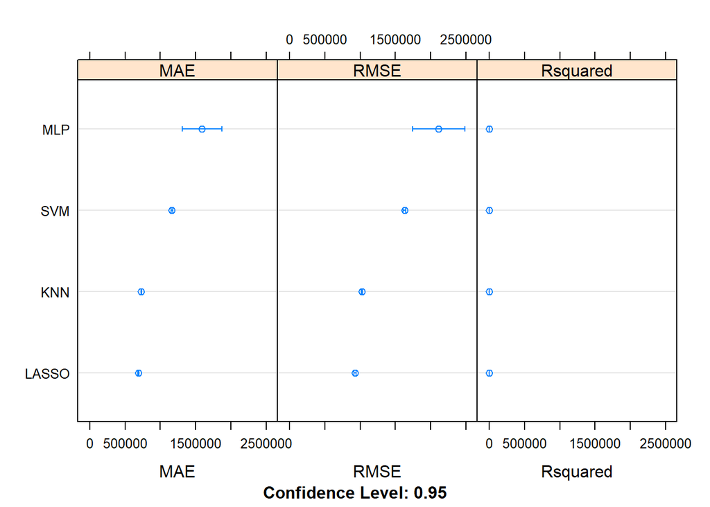

```r
dotplot(remuestreos1)
```

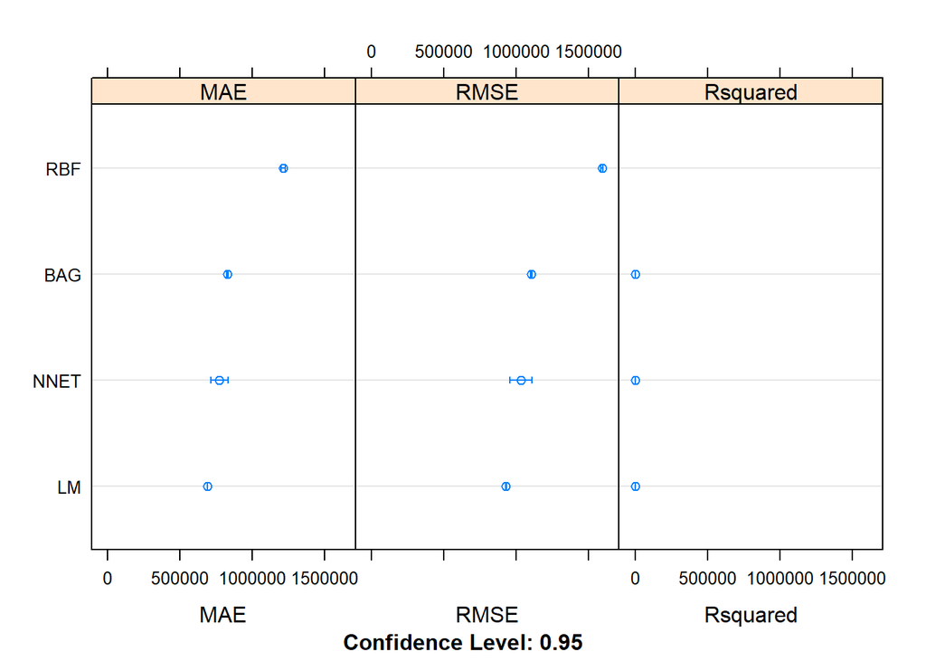

```r
dotplot(remuestreos2)
```

Aquí podemos ver de forma gráfica lo comentado anteriormente sobre las diferencias de las medidas de ajuste entre los distintos modelos.

```r
summary(diferencias)
```

```
##
## Call:
## summary.diff.resamples(object = diferencias)
##
## p-value adjustment: bonferroni
## Upper diagonal: estimates of the difference
## Lower diagonal: p-value for H0: difference = 0
##
## MAE
##       KNN           MLP       SVM           LASSO
## KNN                 -863042   -433749         39684
## MLP   0.0060704                429293        902726
## SVM   0.00000010610 0.0768011                473433
## LASSO 0.0004114     0.0052334 0.00000003721
##
## RMSE
##       KNN          MLP      SVM          LASSO
## KNN                -1087160  -604123        98554
## MLP   0.008052                483037      1185713
## SVM   0.0000008369 0.138111                702676
## LASSO 0.0000959687 0.005869 0.0000001719
##
## Rsquared
##       KNN         MLP         SVM         LASSO
## KNN                0.5725      0.1857     -0.0701
## MLP   0.000030292             -0.3868     -0.6426
## SVM   0.000003912 0.0001748               -0.2558
## LASSO 0.0003156   0.000014231 0.000008120
```

Vemos tres matrices (una por cada medida), en las que se muestran las diferencias estimadas entre los modelos en la diagonal superior, y el p-valor en la diagonal inferior.

Excepto para las medidas RMSE y MAE de SVM y MLP, vemos que la mayor parte tienen un p-valor menor a 0.05, lo que indica que se rechazaría la hipótesis nula de igualdad de medidas. Es decir, que las medidas de los modelos son distintas, y por tanto, se podría decir que **LASSO** es realmente uno de los modelos que mejor predice.

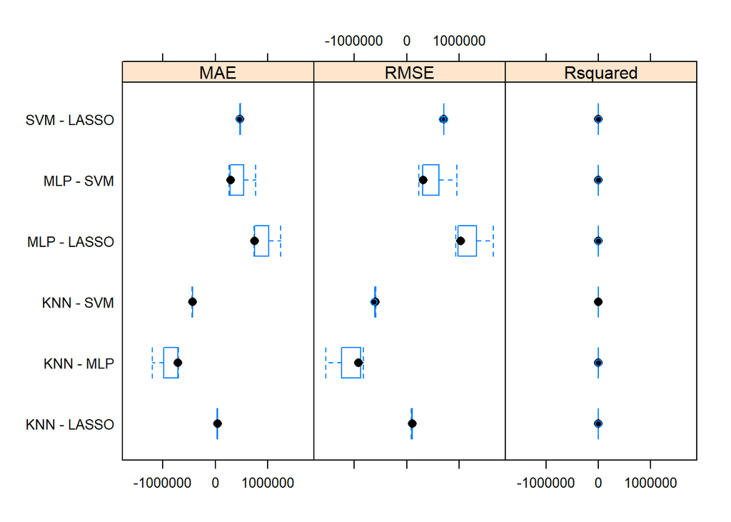

```r
bwplot(diferencias, layout=c(3,1))
```

*Nota: no hemos podido comprobar si sucedía lo mismo con LM, que era el otro modelo con mejor ajuste, debido al error en el cálculo de las diferencias del segundo grupo de modelos*

**Dificultades experimentadas**

A lo largo del examen he indicado con pequeñas notas las dificultades que he tenido y los motivos por los que no se han podido ejecutar o realizar ciertos análisis. Debido a la gran cantidad de observaciones, y la baja capacidad computacional de mi ordenador, he decidido ejecutar los algoritmos directamente con unos parámetros constantes en lugar de probarlos con varios y quedarme con el mejor. De todos modos he indicado en pequeños comentarios los posibles parámetros que se podrían haber utilizado.

Tampoco he podido incluir los modelos CART (con rpart, sí se ha incluído el Bagging CART) y Gradient Boosting, los cuales podrían ser interesantes, debido al siguiente error:

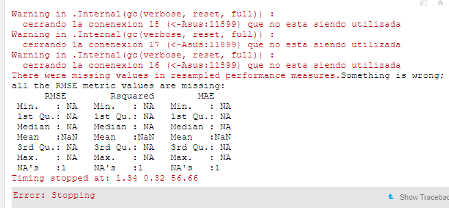

Intenté resolverlo de distintas maneras tras comprobar que no había valores ausentes, como cambiando los parámetros de tuneGrid y de Cross-Validation, eliminando distintas variables que pudiesen estar influyendo, cambiarlas de factor a numéricas, pero sin éxito. Debido a esto decidí no incluir estos modelos.

Comentar que como el enunciado indicaba que el tiempo que estuviese el inmueble anunciado, podría influir en el precio, comprobé el ajuste de un par de modelos con la variable duración (calculada con lubridate). Vi que no mejoraban significativamente, por lo que decidí mantener la variable fecha como estaba. Así es como calculé dicha variable:

```r
#suppressPackageStartupMessages(library(lubridate))
#fecha_fin <- make_date(year = "2021", month = "05", day = "31")
#intervalo <- datosOK$date%--%fecha_fin
#datosOK$duracion <- as.duration(intervalo)
#datosOK$duracion <- as.numeric(duracion)
```